# Meta-analysis on the effects of temperature on sexual selection

García-Roa, R., Garcia-Gonzalez, F., Noble, D.W.A. & Carazo, P.

10 June, 2020

# 1 Setting up and Data Exploration

### 1.0.1 Load Packages

```r
    pacman::p_load(metafor, MCMCglmm, tidyverse, rotl, magrittr, kableExtra, rmarkdown, gridExtra, psych, metaAidR, bindrcpp, pander)
```

### 1.0.2 Load Data

First, lets load the data into R:

```r
    data <- read.csv("../data_Temp_SS.csv", stringsAsFactors = FALSE)
```

Now that it is in we can view the data structure. Note that all factors should be characters. Also, we need to do some cleaning of the data before continuing as well as a little data exploration to check the data for consistencies, such as spelling mistakes etc.

```r
    str(data)
```

```
## 'data.frame':    49 obs. of  29 variables:
##  $ study               : int  1 1 1 1 13 13 13 13 13 24 ...
##  $ author              : chr  "Berger" "Berger" "Berger" "Berger" ...
##  $ year                : int  2014 2014 2014 2014 2006 2006 2006 2006 2006 2014 ...
##  $ journal             : chr  "Evolution" "Evolution" "Evolution" "Evolution" ...
##  $ vol                 : int  68 68 68 68 20 20 20 20 20 28 ...
##  $ sex                 : chr  "males" "females" "males" "females" ...
##  $ genus               : chr  "Callosobruchus" "Callosobruchus" "Callosobruchus" "Callosobruchus" ...
##  $ species             : chr  "maculatus" "maculatus" "maculatus" "maculatus" ...
##  $ group               : chr  "insect" "insect" "insect" "insect" ...
##  $ source              : chr  "fig. 1" "fig. 1" "fig. 1" "fig. 1" ...
##  $ variable            : chr  "Total number of offspring (LRS)" "Total number of offspring (LRS)" "Total number of offspring (LRS)" "Total number of offspring (LRS)" ...
##  $ depend              : int  0 0 0 0 0 0 0 0 0 1 ...
##  $ Tadapt              : chr  "27-29" "27-29" "27-29" "27-29" ...
##  $ T1                  : int  29 29 29 29 25 25 25 25 25 15 ...
##  $ T2                  : int  36 36 36 36 30 30 30 30 30 25 ...
##  $ X_T1                : num  53.646 54.692 48.751 48.983 0.331 ...
##  $ Err_T1              : num  3.8019 2.2098 3.2825 2.116 0.0134 ...
##  $ N_T1                : num  41 41 32 32 31 31 31 31 31 20 ...
##  $ X_T2                : num  29.312 33.488 19.071 22.047 0.324 ...
##  $ Err_T2              : num  3.379 2.24 2.116 2.21 0.013 ...
##  $ N_T2                : num  41 41 32 32 27 27 27 26 26 20 ...
##  $ Err_T1_Type         : chr  "SE" "SE" "SE" "SE" ...
##  $ Err_T2_Type         : chr  "SE" "SE" "SE" "SE" ...
##  $ temp.range          : chr  "stress" "stress" "stress" "stress" ...
##  $ temp.treatment.stage: chr  "lifetime" "lifetime" "lifetime" "lifetime" ...
##  $ endo.ecto           : chr  "ecto" "ecto" "ecto" "ecto" ...
##  $ fitness             : chr  "direct" "direct" "direct" "direct" ...
##  $ prop                : int  0 0 0 0 0 0 0 0 0 1 ...
##  $ notes               : chr  "lome" "lome" "ofuya" "ofuya" ...
```

There are clearly a few things that need to be sorted. First, we need to convert all SE estimates to their corresponding SD. We can apply a couple simple functions to do this. We can then subset the data out for males and females, we’ll run a subset analysis for each dataset as we expect very strong differences between these effect sizes, and potentially differences in how moderators affect the effects.

```r
    # Convert everything to SD from SE
se_to_sd <- function(se, n){
  sd = se*sqrt(n)
  return(sd)
}

convert_to_SD <- function(data){
  data$Err_T1 <- ifelse(data$Err_T1_Type == "SE", se_to_sd(data$Err_T1, data$N_T1), data$Err_T1)
  data$Err_T2 <- ifelse(data$Err_T2_Type == "SE", se_to_sd(data$Err_T2, data$N_T2), data$Err_T2)
  return(data)
}

data <- convert_to_SD(data)

# Add in a species identifier
data$spp <- gsub(" ", "", paste0(data$genus, "_", data$species))

# Add a new variable describing the temperature difference between treatments. We will scale this so that when we fit models the intercept is automatically at the "average" temperature across studies
data$deltaT <- as.numeric(scale(data$T2 - data$T1))

# Extract male data, and because errors are converted to SD now, we can exclude the Err_type columns. We also want to add an observation-level random effect
males <- filter(data, sex == "males")[, -match(c("Err_T1_Type","Err_T2_Type"), colnames(data))]
males$obs <- 1:nrow(males)

females <- filter(data, sex == "females")[, -match(c("Err_T1_Type","Err_T2_Type"), colnames(data))]
females$obs <- 1:nrow(females)
```

We’ll now use the `males` and `females` datasets throughout for data exploration and summary statistics before we do some meta-analysis with subsets of them. We can generate the effect sizes and corresponding sampling variance for each dataset. We can use Wolfgang’s very excellent, and comprehensive, `escalc` function to generate (bias corrected) versions of lnVR and lnCVR and also lnRR, which we can then add to the dataset. We’ll create separate datasets so it’s clear which effect size we are using, but these could easily be all merged into one. We just find it easier to have them separated so that we can change the dataset. What we want to do is “subtract” log(T1) from log(T2), summary statistics. In other words, when the effect size is negative, it means that the higher temperature (T2) has a smaller mean or variance compared with the lower temperature (T1). When the effect size is positive, it means that T1 has a smaller mean or variance than T2. We can see how this works quite easily by checking results form a few simple ratios. For example, `log(2/1)` = 0.69 is positive and we can see that the numerator is larger than the denominator. In contrast, `log(1/2)` = -0.69 is the same estimate, but negative and we can see that the numerator is smaller than the denominator. All we are essentially doing then is calculating the following ratio: `log(T2/T1)`. We can even convert this to a more interpretable value, which will will do a little later, by exponentiating the resulting value. So, for example, `exp(log(1/2))` = 0.5, which means that the numerator (i.e., T2) is 50% smaller than the denominator. To give you another example, if `exp(log(1.5/2))` = 0.75, which means that the numerator (i.e., T2) is 25% smaller than the denominator. If, for example, the ratios were reversed such that, we have `exp(log(2/1.5))` = 1.33 then this would mean that the numerator is 33.33% larger than the denominator. This same interpretation applies to lnVR and lnCVR when we talk about variances.

```r
    lnRR_males <- metafor::escalc(measure= "ROM", m1i= X_T2, m2i = X_T1, sd1i= Err_T2, sd2i= Err_T1, n1i =N_T2, n2i=N_T1,  append = TRUE, data = males)
    lnVR_males <- metafor::escalc(measure= "VR", m1i= X_T2, m2i = X_T1, sd1i= Err_T2, sd2i= Err_T1, n1i =N_T2, n2i=N_T1,  append = TRUE, data = males)
 lnCVR_males <- metafor::escalc(measure= "CVR", m1i= X_T2, m2i = X_T1, sd1i= Err_T2, sd2i= Err_T1, n1i =N_T2, n2i=N_T1,  append = TRUE, data = males)
```

We can then do the same for the females:

```r
lnRR_females <- metafor::escalc(measure= "ROM", m1i= X_T2, m2i = X_T1, sd1i= Err_T2, sd2i= Err_T1, n1i =N_T2, n2i=N_T1,  append = TRUE, data = females)
lnVR_females <- metafor::escalc(measure= "VR", m1i= X_T2, m2i = X_T1, sd1i= Err_T2, sd2i= Err_T1, n1i =N_T2, n2i=N_T1,  append = TRUE, data = females)
lnCVR_females <- metafor::escalc(measure= "CVR", m1i= X_T2, m2i = X_T1, sd1i= Err_T2, sd2i= Err_T1, n1i =N_T2, n2i=N_T1,  append = TRUE, data = females)
```

Now we have size datasets with the effect size, `yi`, being the relevant ratio of means, standard deviations and coefficient of variations, for males and females and `vi` being the corresponding sampling variance. These datasets can then be substituted into the models to estimate overall effects, how moderators impact variance and the variation in effects overall.

### 1.0.3 Data Exploration

Now that we have the `males` and `females` data created we can start some data exploration. We can first view these datasets, the raw data, if we want first. Since we have three different effect sizes, we’ll just view the lnRR datasets for both sexes, but the raw data for each are provided should the reader be interested in looking at them all.

We’ll look at the female data first. It’s smaller:

```r
    # Word / pdf table
    pander(lnRR_females)
```

Table continues below

| study | author | year | journal | vol |
| --- | --- | --- | --- | --- |
| 1 | Berger | 2014 | Evolution | 68 |
| 1 | Berger | 2014 | Evolution | 68 |
| 9 | Dubey | 2016 | Journal of Thermal Biology | 58 |
| 9 | Dubey | 2016 | Journal of Thermal Biology | 58 |
| 14 | Grazer | 2012 | Evolutionary Ecology | 26 |
| 23 | Martinossi-Allibert | 2017 | Journal of Evolutionary Biology | 30 |
| 30 | Sambucetti | 2014 | Entomologia Experimentalis et Applicata | 154 |
| 30 | Sambucetti | 2014 | Entomologia Experimentalis et Applicata | 154 |
| 4 | Tregenza | 2003 | Evolution | 57 |
| 8 | Plesnar-Bielak | 2012 | Proceedings of the Royal Society B-Biological Sciences | 279 |
| 8 | Plesnar-Bielak | 2012 | Proceedings of the Royal Society B-Biological Sciences | 279 |
| 8 | Plesnar-Bielak | 2012 | Proceedings of the Royal Society B-Biological Sciences | 279 |
| 11 | McCabe | 1997 | Evolution | 51 |
| 11 | McCabe | 1997 | Evolution | 51 |
| 11 | McCabe | 1997 | Evolution | 51 |
| 17 | Fairbairn | 2005 | The American Naturalist | 166 |
| 17 | Fairbairn | 2005 | The American Naturalist | 166 |
| 17 | Fairbairn | 2005 | The American Naturalist | 166 |

Table continues below

| sex | genus | species | group | source |
| --- | --- | --- | --- | --- |
| females | Callosobruchus | maculatus | insect | fig. 1 |
| females | Callosobruchus | maculatus | insect | fig. 1 |
| females | Menochilus | sexmaculatus | insect | table A3 |
| females | Menochilus | sexmaculatus | insect | table A3 |
| females | Tribolium | castneum | insect | fig. 2 |
| females | Callosobruchus | maculatus | insect | fig. 2 |
| females | Drosophila | buzzatii | insect | fig. 2 |
| females | Drosophila | buzzatii | insect | fig. 2 |
| females | Scathophaga | stercoraria | insect | fig. 2 |
| females | Rhizoglyphus | robini | arachnid | text |
| females | Rhizoglyphus | robini | arachnid | raw |
| females | Rhizoglyphus | robini | arachnid | raw |
| females | Drosophila | melanogaster | insect | fig. 8 |
| females | Drosophila | melanogaster | insect | fig. 8 |
| females | Drosophila | melanogaster | insect | fig. 8 |
| females | Aquarius | remigis | insect | fig. 5 |
| females | Aquarius | remigis | insect | fig. 5 |
| females | Aquarius | remigis | insect | fig. 5 |

Table continues below

| variable | depend | Tadapt | T1 | T2 | X_T1 |
| --- | --- | --- | --- | --- | --- |
| Total number of offspring (LRS) | 0 | 27-29 | 29 | 36 | 54.69 |
| Total number of offspring (LRS) | 0 | 27-29 | 29 | 36 | 48.98 |
| Number of eggs (Fecundity/Reproductive success) | 0 | NA | 15 | 35 | 77.4 |
| Number of eggs (Fecundity/Reproductive success) | 0 | NA | 15 | 35 | 79.65 |
| Reproductive success | 0 | 30 | 30 | 34 | 179.2 |
| Total fitness (survival & LRS) | 0 | 27-29 | 29 | 37 | 0.9919 |
| Proportion of mated flies | 0 | NA | 25 | 33 | 0.4159 |
| Proportion of mated flies | 0 | NA | 25 | 33 | 0.5858 |
| Mean proportion of eggs hatched | 0 | NA | 11 | 19 | 0.556 |
| Mean number of eggs per female | 0 | 24 (18 gen at 28) | 24 | 28 | 163.9 |
| Mean number of eggs per female | 0 | 24 (18 gen at 28) | 24 | 28 | 143.1 |
| Mean number of eggs per female | 0 | 24 (18 gen at 28) | 24 | 28 | 118.3 |
| Lifetime number of progeny | 0 | 25 | 18 | 25 | 553.4 |
| Lifetime number of progeny | 0 | 25 | 18 | 25 | 493.6 |
| Lifetime number of progeny | 0 | 25 | 18 | 25 | 730.6 |
| log(abdomin length) | 0 | NA | 20 | 25 | 0.775 |
| log(abdomin length) | 0 | NA | 20 | 25 | 0.7906 |
| log(abdomin length) | 0 | NA | 20 | 25 | 0.8133 |

Table continues below

| Err_T1 | N_T1 | X_T2 | Err_T2 | N_T2 | temp.range | temp.treatment.stage |
| --- | --- | --- | --- | --- | --- | --- |
| 14.15 | 41 | 33.49 | 14.34 | 41 | stress | lifetime |
| 11.97 | 32 | 22.05 | 12.5 | 32 | stress | lifetime |
| 4.736 | 20 | 104.3 | 4.53 | 20 | natural | lifetime |
| 3.229 | 20 | 108.5 | 3.774 | 20 | natural | lifetime |
| 180.5 | 60 | 223.2 | 151.6 | 60 | natural | lifetime |
| 0.1553 | 14 | 0.3375 | 0.1278 | 14 | stress | juvenile |
| 0.2171 | 6 | 0.5411 | 0.3256 | 6 | natural | adults |
| 0.211 | 6 | 0.5012 | 0.2164 | 6 | stress | adults |
| 0.4313 | 36 | 0.9113 | 0.4557 | 36 | natural | lifetime |
| 88.25 | 31 | 47.53 | 32.79 | 31 | stress | lifetime |
| 49.84 | 46.8 | 76.15 | 40.45 | 33.4 | stress | lifetime |
| 47.01 | 43.1 | 92.86 | 43.42 | 40.6 | stress | lifetime |
| 382.9 | 88 | 374.1 | 335.7 | 88 | stress | lifetime |
| 348.1 | 88 | 343.7 | 319.8 | 88 | stress | lifetime |
| 364.8 | 88 | 413.1 | 253.6 | 88 | stress | lifetime |
| 0.02237 | 11 | 0.7578 | 0.05618 | 11 | natural | lifetime |
| 0.01512 | 11 | 0.7799 | 0.01542 | 11 | natural | lifetime |
| 0.01723 | 11 | 0.8093 | 0.01378 | 11 | natural | lifetime |

Table continues below

| endo.ecto | fitness | prop | notes |
| --- | --- | --- | --- |
| ecto | direct | 0 | lome |
| ecto | direct | 0 | ofuya |
| ecto | direct | 0 | TxT |
| ecto | direct | 0 | MxM |
| ecto | direct | 0 |  |
| ecto | direct | 0 |  |
| ecto | direct | 1 | Chumbicha - low |
| ecto | direct | 1 | Quilmes - high |
| ecto | direct | 1 |  |
| ecto | direct | 0 | In text pilot data, wild type |
| ecto | direct | 0 | 24_Polygamy_SL |
| ecto | direct | 0 | 28_Polygamy_SL |
| ecto | direct | 0 | control lines |
| ecto | direct | 0 | small wing selection |
| ecto | direct | 0 | large wing selection |
| ecto | indirect | 0 | SW population |
| ecto | indirect | 0 | DLM population |
| ecto | indirect | 0 | SCI population |

| spp | deltaT | obs | yi | vi |
| --- | --- | --- | --- | --- |
| Callosobruchus_maculatus | -0.1491 | 1 | -0.4905 | 0.006106 |
| Callosobruchus_maculatus | -0.1491 | 2 | -0.7983 | 0.01191 |
| Menochilus_sexmaculatus | 3.649 | 3 | 0.2983 | 0.0002815 |
| Menochilus_sexmaculatus | 3.649 | 4 | 0.3086 | 0.0001427 |
| Tribolium_castneum | -1.026 | 5 | 0.2195 | 0.02461 |
| Callosobruchus_maculatus | 0.1431 | 6 | -1.078 | 0.01199 |
| Drosophila_buzzatii | 0.1431 | 7 | 0.2631 | 0.1057 |
| Drosophila_buzzatii | 0.1431 | 8 | -0.1561 | 0.05271 |
| Scathophaga_stercoraria | 0.1431 | 9 | 0.4941 | 0.02366 |
| Rhizoglyphus_robini | -1.026 | 10 | -1.238 | 0.02471 |
| Rhizoglyphus_robini | -1.026 | 11 | -0.6311 | 0.01104 |
| Rhizoglyphus_robini | -1.026 | 12 | -0.2421 | 0.00905 |
| Drosophila_melanogaster | -0.1491 | 13 | -0.3916 | 0.01459 |
| Drosophila_melanogaster | -0.1491 | 14 | -0.3618 | 0.01549 |
| Drosophila_melanogaster | -0.1491 | 15 | -0.5702 | 0.007115 |
| Aquarius_remigis | -0.7334 | 16 | -0.02248 | 0.0005754 |
| Aquarius_remigis | -0.7334 | 17 | -0.0136 | 6.878e-05 |
| Aquarius_remigis | -0.7334 | 18 | -0.005019 | 6.717e-05 |

```r
    #kable(lnRR_females) %>%
    #kable_styling(font = 11) %>%
    #scroll_box(width = "100%", height = "200px")
```

Then we can look at the male data, it’s a bit more as many studies quantify and seem to be interested mostly in male fitness (or fitness proxies) for sexual selection. At least in the context of temperature manipulations:

```r
   # Word / pdf table
    pander(lnRR_males)
```

Table continues below

| study | author | year | journal | vol |
| --- | --- | --- | --- | --- |
| 1 | Berger | 2014 | Evolution | 68 |
| 1 | Berger | 2014 | Evolution | 68 |
| 13 | Fox | 2006 | Functional Ecology | 20 |
| 13 | Fox | 2006 | Functional Ecology | 20 |
| 13 | Fox | 2006 | Functional Ecology | 20 |
| 13 | Fox | 2006 | Functional Ecology | 20 |
| 13 | Fox | 2006 | Functional Ecology | 20 |
| 24 | Mehlis | 2014 | Evolutionary Ecology | 28 |
| 24 | Mehlis | 2014 | Evolutionary Ecology | 28 |
| 24 | Mehlis | 2014 | Evolutionary Ecology | 28 |
| 24 | Mehlis | 2014 | Evolutionary Ecology | 28 |
| 25 | Nguyen | 2013 | Journal of Insect Physiology | 59 |
| 40 | Wilson | 2005 | Animal Behaviour | 70 |
| 32 | Saxon | 2018 | Journal of Evolutionary Bilogy | 31 |
| 23 | Martinossi-Allibert | 2017 | Journal of Evolutionary Biology | 30 |
| 28 | Plesnar-Bielak | 2018 | BMC Evolutionary Biology | 18 |
| 30 | Sambucetti | 2014 | Entomologia Experimentalis et Applicata | 154 |
| 30 | Sambucetti | 2014 | Entomologia Experimentalis et Applicata | 154 |
| 37 | Vasudeva | 2014 | Journal of Evolutionary Biology | 27 |
| 37 | Vasudeva | 2014 | Journal of Evolutionary Biology | 27 |
| 37 | Vasudeva | 2014 | Journal of Evolutionary Biology | 27 |
| 37 | Vasudeva | 2014 | Journal of Evolutionary Biology | 27 |
| 41 | Yenisetti | 2006 | Korean Journal of Genetics | 28 |
| 41 | Yenisetti | 2006 | Korean Journal of Genetics | 28 |
| 6 | Reeve | 2000 | Journal of Evolutionary Biology | 13 |
| 6 | Reeve | 2000 | Journal of Evolutionary Biology | 13 |
| 6 | Reeve | 2000 | Journal of Evolutionary Biology | 13 |
| 7 | Polak | 2012 | Journal of Evolutionary Biology | 25 |
| 17 | Fairbairn | 2005 | The American Naturalist | 166 |
| 17 | Fairbairn | 2005 | The American Naturalist | 166 |
| 17 | Fairbairn | 2005 | The American Naturalist | 166 |

Table continues below

| sex | genus | species | group | source |
| --- | --- | --- | --- | --- |
| males | Callosobruchus | maculatus | insect | fig. 1 |
| males | Callosobruchus | maculatus | insect | fig. 1 |
| males | Callosobruchus | maculatus | insect | fig. 1A |
| males | Callosobruchus | maculatus | insect | fig. 1A |
| males | Callosobruchus | maculatus | insect | fig. 1A |
| males | Callosobruchus | maculatus | insect | fig. 1A |
| males | Callosobruchus | maculatus | insect | fig. 1A |
| males | Gasterosteus | aculeatus | fish | fig. 1 |
| males | Gasterosteus | aculeatus | fish | fig. 1 |
| males | Gasterosteus | aculeatus | fish | fig. 2B |
| males | Gasterosteus | aculeatus | fish | fig. 2C |
| males | Anisopteromalus | calandrae | insect | fig. 2 |
| males | Gambusia | holbrooki | fish | fig. 4 |
| males | Drosophila | birchii | insect | fig. 1I |
| males | Callosobruchus | maculatus | insect | fig. 2 |
| males | Rhizoglyphus | robini | insect | fig. 4 |
| males | Drosophila | buzzatii | insect | fig. 2 |
| males | Drosophila | buzzatii | insect | fig. 2 |
| males | Callosobruchus | maculatus | insect | fig. 2 |
| males | Callosobruchus | maculatus | insect | fig. 2 |
| males | Callosobruchus | maculatus | insect | fig. 2 |
| males | Callosobruchus | maculatus | insect | fig. 2 |
| males | Phorticella | striata | insect | table 1 |
| males | Phorticella | striata | insect | table 1 |
| males | Drosophila | melanogaster | insect | fig. 2 |
| males | Drosophila | melanogaster | insect | fig. 2 |
| males | Drosophila | melanogaster | insect | fig. 2 |
| males | Drosophila | bipectinata | insect | table 3 |
| males | Aquarius | remigis | insect | fig. 5 |
| males | Aquarius | remigis | insect | fig. 5 |
| males | Aquarius | remigis | insect | fig. 5 |

Table continues below

| variable | depend | Tadapt | T1 | T2 |
| --- | --- | --- | --- | --- |
| Total number of offspring (LRS) | 0 | 27-29 | 29 | 36 |
| Total number of offspring (LRS) | 0 | 27-29 | 29 | 36 |
| mg Mass loss (Male Investment) | 0 | NA | 25 | 30 |
| mg Mass loss (Male Investment) | 0 | NA | 25 | 30 |
| mg Mass loss (Male Investment) | 0 | NA | 25 | 30 |
| mg Mass loss (Male Investment) | 0 | NA | 25 | 30 |
| mg Mass loss (Male Investment) | 0 | NA | 25 | 30 |
| Mean Fertilization Success at 100,000 sperm (%) | 1 | NA | 15 | 25 |
| Mean Fertilization Success at 1,000,000 sperm (%) | 1 | NA | 15 | 25 |
| Sperm Linearity (PCA) | 2 | NA | 15 | 25 |
| Mean Motile Sperm (%) | 2 | NA | 15 | 25 |
| Number of Sperm in Vesicles | 0 | 30 | 30 | 36 |
| Number of Copulations Per Minute | 0 | NA | 18 | 26 |
| Total number of offspring | 0 | NA | 17 | 24 |
| Total fitness (survival & LRS) | 0 | 27-29 | 29 | 37 |
| Percentage of egg sired by fighers (reproductive success) | 0 | 24 (EE at 18 for 14 gen)) | 18 | 24 |
| Proportion of mated flies | 0 | NA | 25 | 33 |
| Proportion of mated flies | 0 | NA | 25 | 33 |
| Sperm number (1000x) | 1 | 27 | 25 | 33 |
| Sperm Length (mm) | 1 | 27 | 25 | 33 |
| Sperm number (1000x) | 2 | 27 | 25 | 33 |
| Sperm Length (mm) | 2 | 27 | 25 | 33 |
| Copulation duration | 0 | NA | 15 | 29 |
| Copulation duration | 0 | NA | 15 | 29 |
| Proportion of wild-type progeny sired (fertility) | 0 | 25 | 18 | 25 |
| Proportion of wild-type progeny sired (fertility) | 0 | 25 | 18 | 25 |
| Proportion of wild-type progeny sired (fertility) | 0 | 25 | 18 | 25 |
| CT1 Comb Number | 0 | NA | 25 | 29 |
| log(genital length) | 0 | NA | 20 | 25 |
| log(genital length) | 0 | NA | 20 | 25 |
| log(genital length) | 0 | NA | 20 | 25 |

Table continues below

| X_T1 | Err_T1 | N_T1 | X_T2 | Err_T2 | N_T2 | temp.range |
| --- | --- | --- | --- | --- | --- | --- |
| 53.65 | 24.34 | 41 | 29.31 | 21.64 | 41 | stress |
| 48.75 | 18.57 | 32 | 19.07 | 11.97 | 32 | stress |
| 0.3309 | 0.07481 | 31 | 0.3238 | 0.06756 | 27 | natural |
| 0.3436 | 0.08064 | 31 | 0.2984 | 0.08625 | 27 | natural |
| 0.327 | 0.07153 | 31 | 0.2882 | 0.0603 | 27 | natural |
| 0.3065 | 0.06058 | 31 | 0.2603 | 0.05971 | 26 | natural |
| 0.2614 | 0.07679 | 31 | 0.2105 | 0.05695 | 26 | natural |
| 37.9 | 28.98 | 20 | 60.69 | 36.05 | 20 | natural |
| 89 | 14.28 | 20 | 77.36 | 29.39 | 20 | natural |
| 0.4829 | 1.36 | 12 | 0.6836 | 1.852 | 12 | natural |
| 30.99 | 12.71 | 12 | 24.05 | 10.82 | 12 | natural |
| 3203 | 1211 | 56 | 1425 | 1296 | 30 | stress |
| 0.322 | 0.255 | 14 | 0.2302 | 0.1505 | 14 | natural |
| 100.4 | 74.35 | 20 | 172.6 | 87.26 | 20 | natural |
| 1.006 | 0.3741 | 14 | 0.07857 | 0.07287 | 14 | stress |
| 49 | 29.89 | 37 | 41.1 | 33.38 | 16 | stress |
| 0.5925 | 0.1737 | 6 | 0.3602 | 0.1647 | 6 | natural |
| 0.4065 | 0.1745 | 6 | 0.6426 | 0.1485 | 6 | stress |
| 69.23 | 26.18 | 18 | 37.8 | 24.84 | 18 | stress |
| 0.166 | 0.008973 | 18 | 0.1668 | 0.01188 | 18 | stress |
| 58.33 | 48.78 | 18 | 45.58 | 52.7 | 18 | stress |
| 0.1702 | 0.005066 | 18 | 0.1665 | 0.009039 | 18 | stress |
| 186.4 | 19.1 | 25 | 202.1 | 38.25 | 25 | natural |
| 192.2 | 25.7 | 25 | 229.5 | 56.65 | 25 | natural |
| 0.204 | 0.08148 | 13 | 0.1681 | 0.04403 | 13 | stress |
| 0.195 | 0.1377 | 13 | 0.1454 | 0.04848 | 13 | stress |
| 0.1591 | 0.08497 | 13 | 0.14 | 0.04043 | 13 | stress |
| 5.835 | 0.6737 | 134 | 5.74 | 0.9376 | 134 | natural |
| 0.3961 | 0.04639 | 11 | 0.3933 | 0.03454 | 11 | stress |
| 0.4048 | 0.01413 | 11 | 0.3991 | 0.01346 | 11 | natural |
| 0.4754 | 0.01626 | 11 | 0.4625 | 0.0465 | 11 | natural |

Table continues below

| temp.treatment.stage | endo.ecto | fitness | prop | notes |
| --- | --- | --- | --- | --- |
| lifetime | ecto | direct | 0 | lome |
| lifetime | ecto | direct | 0 | ofuya |
| lifetime | ecto | indirect | 0 | Burkina Faso_Azuki |
| lifetime | ecto | indirect | 0 | Burkina Faso_Cowpea |
| lifetime | ecto | indirect | 0 | Burkina Faso_Mung |
| lifetime | ecto | indirect | 0 | South India_Azuki |
| lifetime | ecto | indirect | 0 | South India_Cowpea |
| adults | ecto | indirect | 1 |  |
| adults | ecto | indirect | 1 |  |
| adults | ecto | indirect | 0 |  |
| adults | ecto | indirect | 1 |  |
| early | ecto | indirect | 0 |  |
| adults | ecto | direct | 0 |  |
| lifetime | ecto | direct | 0 |  |
| juvenile | ecto | direct | 0 |  |
| lifetime | ecto | direct | 1 |  |
| adults | ecto | direct | 1 | Chumbicha - low |
| adults | ecto | direct | 1 | Quilmes - high |
| lifetime | ecto | indirect | 0 | replicate 1 |
| lifetime | ecto | indirect | 0 | replicate 1 |
| lifetime | ecto | indirect | 0 | replicate 2 |
| lifetime | ecto | indirect | 0 | replicate 2 |
| adults | ecto | indirect | 0 | Mysore |
| adults | ecto | indirect | 0 | Ahmedabad |
| lifetime | ecto | direct | 1 | control line 1 |
| lifetime | ecto | direct | 1 | control line 2 |
| lifetime | ecto | direct | 1 | control line 3 |
| lifetime | ecto | indirect | 0 |  |
| lifetime | ecto | indirect | 0 | SW population |
| lifetime | ecto | indirect | 0 | DLM population |
| lifetime | ecto | indirect | 0 | SCI population |

| spp | deltaT | obs | yi | vi |
| --- | --- | --- | --- | --- |
| Callosobruchus_maculatus | -0.1491 | 1 | -0.6044 | 0.01831 |
| Callosobruchus_maculatus | -0.1491 | 2 | -0.9386 | 0.01684 |
| Callosobruchus_maculatus | -0.7334 | 3 | -0.02174 | 0.003262 |
| Callosobruchus_maculatus | -0.7334 | 4 | -0.1408 | 0.00487 |
| Callosobruchus_maculatus | -0.7334 | 5 | -0.1262 | 0.003164 |
| Callosobruchus_maculatus | -0.7334 | 6 | -0.1636 | 0.003285 |
| Callosobruchus_maculatus | -0.7334 | 7 | -0.2166 | 0.005601 |
| Gasterosteus_aculeatus | 0.7275 | 8 | 0.4709 | 0.04689 |
| Gasterosteus_aculeatus | 0.7275 | 9 | -0.1402 | 0.008506 |
| Gasterosteus_aculeatus | 0.7275 | 10 | 0.3477 | 1.273 |
| Gasterosteus_aculeatus | 0.7275 | 11 | -0.2534 | 0.03088 |
| Anisopteromalus_calandrae | -0.4413 | 12 | -0.81 | 0.03012 |
| Gambusia_holbrooki | 0.1431 | 13 | -0.3355 | 0.07531 |
| Drosophila_birchii | -0.1491 | 14 | 0.5414 | 0.04018 |
| Callosobruchus_maculatus | 0.1431 | 15 | -2.55 | 0.07131 |
| Rhizoglyphus_robini | -0.4413 | 16 | -0.1757 | 0.05128 |
| Drosophila_buzzatii | 0.1431 | 17 | -0.4975 | 0.04918 |
| Drosophila_buzzatii | 0.1431 | 18 | 0.458 | 0.03961 |
| Callosobruchus_maculatus | 0.1431 | 19 | -0.605 | 0.03194 |
| Callosobruchus_maculatus | 0.1431 | 20 | 0.004561 | 0.0004442 |
| Callosobruchus_maculatus | 0.1431 | 21 | -0.2466 | 0.1131 |
| Callosobruchus_maculatus | 0.1431 | 22 | -0.02195 | 0.0002128 |
| Phorticella_striata | 1.896 | 23 | 0.08051 | 0.001853 |
| Phorticella_striata | 1.896 | 24 | 0.177 | 0.003153 |
| Drosophila_melanogaster | -0.1491 | 25 | -0.1933 | 0.01755 |
| Drosophila_melanogaster | -0.1491 | 26 | -0.2935 | 0.04692 |
| Drosophila_melanogaster | -0.1491 | 27 | -0.1277 | 0.02835 |
| Drosophila_bipectinata | -1.026 | 28 | -0.01642 | 0.0002986 |
| Aquarius_remigis | -0.7334 | 29 | -0.007057 | 0.001948 |
| Aquarius_remigis | -0.7334 | 30 | -0.01432 | 0.0002141 |
| Aquarius_remigis | -0.7334 | 31 | -0.02745 | 0.001025 |

```r
#kable(lnRR_males) %>%
  #kable_styling(font = 11) %>%
  #scroll_box(width = "100%", height = "200px")
```

We can also have a look at the mean-variance relationship in these data:

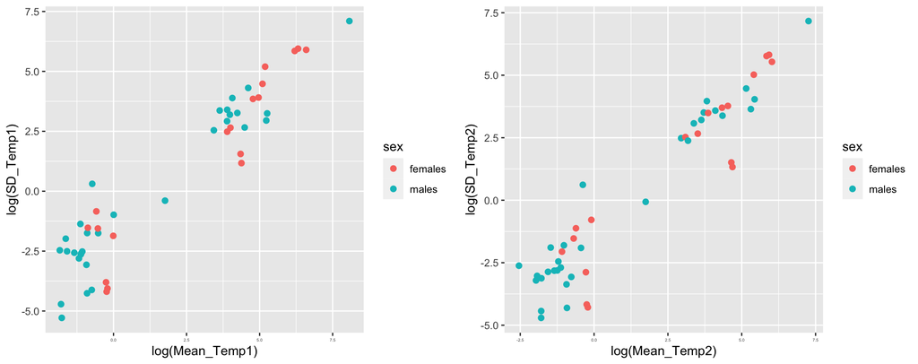

```r
        p1 = ggplot(data, aes(x=log(X_T1), y=log(Err_T1), col = sex)) +
        geom_point(size=2) +
        #theme_bw() +
        theme(axis.text.x=element_text(size=rel(0.4))) +
        labs(x = "log(Mean_Temp1)", y = "log(SD_Temp1)")

        p2 = ggplot(data, aes(x=log(X_T2), y=log(Err_T2), col = sex)) +
        geom_point(size=2) +
        #theme_bw() +
        theme(axis.text.x=element_text(size=rel(0.4))) +
        labs(x = "log(Mean_Temp2)", y = "log(SD_Temp2)")

        grid.arrange(p1,p2, nrow =1)
```

# 2 Multi-level Meta-analytic Models (MLMA)

Now that the datasets are cleaned, effect sizes generated and explored a bit we are now ready to start meta-analysing. We first start with multi-level meta-analytic models (MLMA). These are essentially intercept-only random effects models that account for the known sampling variance of effects along with additional sources of non-independence, such as study and species in a single model. These models are useful for exploring heterogeneity in effects, estimating overall meta-analytic means to understand how temperature affects sexual selection across the entire population of studies and species included in our sample. Effect sizes here are not totally comparable because, as we are well aware, across studies they use different temperatures. However, we are aware of this and what this will essentially do is increase the heterogeneity in effects. Alternatively, this will somewhat get captured by the study-level / species-level random effect because temperature is likely a major driver of between study differences. So, for now, we will assume that effect sizes are comparable and then we can control for temperature differences in meta-regression models below.

## 2.1 Males

We’ll first have a look at the male data and each of the effect sizes of interest.

#### 2.1.0.1 LnRR

```r
    MLMA_male_lnRR <- metafor::rma.mv(yi ~ 1, V = vi, random = list( ~1|study, ~1|spp, ~1|obs), data = lnRR_males)
    summary(MLMA_male_lnRR)
```

```
##
## Multivariate Meta-Analysis Model (k = 31; method: REML)
##
##   logLik  Deviance       AIC       BIC      AICc
## -15.2572   30.5144   38.5144   44.1192   40.1144
##
## Variance Components:
##
##             estim    sqrt  nlvls  fixed  factor
## sigma^2.1  0.4318  0.6571     14     no   study
## sigma^2.2  0.0033  0.0570     11     no     spp
## sigma^2.3  0.0000  0.0000     31     no     obs
##
## Test for Heterogeneity:
## Q(df = 30) = 261.2501, p-val < .0001
##
## Model Results:
##
## estimate      se     zval    pval    ci.lb   ci.ub
##  -0.2932  0.1811  -1.6191  0.1054  -0.6480  0.0617
##
## ---
## Signif. codes:  0 '***' 0.001 '**' 0.01 '*' 0.05 '.' 0.1 ' ' 1
```

Here we can see from the model output that there a high between-study variance in effects, which isn’t totally surprising given what we discussed above. We also see that the overall meta-analytic mean is -0.29 with a 95% CI = -0.65 to 0.06, which tells us that the mean in the T2 treatment tends to be smaller than the mean in the T1 treatment. More specifically, the higher temperature is about 25.41% smaller than the mean at the lower temperature. The overall estimate isn’t significant (approaching it though), but the sample size is small, so we should stay focused on the estimate and its uncertainty.

We can also get estimates of the between study, phylogenetic (if we have one), species and total heterogenity.

```r
  tab <- metaAidR::I2(MLMA_male_lnRR, MLMA_male_lnRR$vi)
  # kable(tab)%>%
  # kable_styling(font = 14)
  #
  pander(tab)
```

|  | I2_Est. | 2.5% CI | 97.5% CI |
| --- | --- | --- | --- |
| **study** | 0.9862 | 0.9669 | 0.9949 |
| **spp** | 0.0088 | 0.0021 | 0.0233 |
| **total** | 0.995 | 0.9895 | 0.9978 |

#### 2.1.0.2 lnVR

```r
    MLMA_male_lnVR <- metafor::rma.mv(yi ~ 1, V = vi, random = list( ~1|study, ~1|spp, ~1|obs), data = lnVR_males)
    summary(MLMA_male_lnVR)
```

```
##
## Multivariate Meta-Analysis Model (k = 31; method: REML)
##
##   logLik  Deviance       AIC       BIC      AICc
## -19.1939   38.3878   46.3878   51.9926   47.9878
##
## Variance Components:
##
##             estim    sqrt  nlvls  fixed  factor
## sigma^2.1  0.2583  0.5082     14     no   study
## sigma^2.2  0.0004  0.0191     11     no     spp
## sigma^2.3  0.0212  0.1457     31     no     obs
##
## Test for Heterogeneity:
## Q(df = 30) = 144.0839, p-val < .0001
##
## Model Results:
##
## estimate      se     zval    pval    ci.lb   ci.ub
##  -0.0624  0.1480  -0.4213  0.6736  -0.3524  0.2277
##
## ---
## Signif. codes:  0 '***' 0.001 '**' 0.01 '*' 0.05 '.' 0.1 ' ' 1
```

Here we can see from the model output that there a moderate between-study variance in effects. We also see that the overall meta-analytic mean is -0.06 with a 95% CI = -0.35 to 0.23, which tells us that the variance in the T2 treatment tends to be smaller than the variance in the T1 treatment, although this is a very small effect size overall. More specifically, the higher temperature is about 6.04% smaller than the lower temperature.

We can also get estimates of the between study, phylogenetic (if we have one), species and total heterogenity.

```r
  tabF <- metaAidR::I2(MLMA_male_lnVR, MLMA_male_lnVR$vi)
  pander(tabF)
```

|  | I2_Est. | 2.5% CI | 97.5% CI |
| --- | --- | --- | --- |
| **study** | 0.7728 | 0.5918 | 0.8841 |
| **spp** | 0.0012 | 3e-04 | 0.003 |
| **total** | 0.8457 | 0.7271 | 0.918 |

```r
  #kable(tabF)%>%
  #kable_styling(font = 14)
```

#### 2.1.0.3 lnCVR

```r
    MLMA_male_lnCVR <- metafor::rma.mv(yi ~ 1, V = vi, random = list( ~1|study, ~1|spp, ~1|obs), data = lnCVR_males)
    summary(MLMA_male_lnCVR)
```

```
##
## Multivariate Meta-Analysis Model (k = 31; method: REML)
##
##   logLik  Deviance       AIC       BIC      AICc
## -18.3442   36.6884   44.6884   50.2932   46.2884
##
## Variance Components:
##
##             estim    sqrt  nlvls  fixed  factor
## sigma^2.1  0.0691  0.2630     14     no   study
## sigma^2.2  0.0448  0.2116     11     no     spp
## sigma^2.3  0.0237  0.1539     31     no     obs
##
## Test for Heterogeneity:
## Q(df = 30) = 77.8102, p-val < .0001
##
## Model Results:
##
## estimate      se    zval    pval    ci.lb   ci.ub
##   0.2195  0.1212  1.8111  0.0701  -0.0180  0.4571  .
##
## ---
## Signif. codes:  0 '***' 0.001 '**' 0.01 '*' 0.05 '.' 0.1 ' ' 1
```

Here we can see from the model output that there a small between-study variance in effects. We also see that the overall meta-analytic mean is 0.22 with a 95% CI = -0.02 to 0.46, which tells us that the variance (controlling for the mean) in the T2 treatment tends to be higher than the variance (controlling for the mean) in the T1 treatment. This effect is approaching significance at p = 0.05. More specifically, the variance (controlling for the mean change) in higher temperature is about 24.55% larger compared to the lower temperature.

We can also get estimates of the between study, phylogenetic (if we have one), species and total heterogenity.

```r
  tab2 <- metaAidR::I2(MLMA_male_lnCVR, MLMA_male_lnCVR$vi)
  pander(tab2)
```

|  | I2_Est. | 2.5% CI | 97.5% CI |
| --- | --- | --- | --- |
| **study** | 0.3431 | 0.1651 | 0.5335 |
| **spp** | 0.2226 | 0.0853 | 0.3936 |
| **total** | 0.688 | 0.5698 | 0.7841 |

```r
 #kable(tab2)%>%
  #kable_styling(font = 14)
```

The one challenge with these effects is that they contain directionality, however, as is indicated in our review, directionality may not be so easily predicted and there are good theoretical reasons to believe that such clear directional predictions do not likely exist. Hence, we can test this by analysing the magnitude of the response. Here we need to do a couple tricks to account for uncertainty and avoid bias.

```r
# Set the prior
prior <- list(R=list(V = 1, nu =0.002), G = list(G1 = list(V=1, nu = 0.002), G2 = list(V=1, nu = 0.002)))

# Run the Bayesian MLMA model
model_magnitude_bayes_males <- MCMCglmm(yi ~ deltaT, mev = lnCVR_males$vi, random = ~study + spp, data = lnCVR_males, prior = prior, burnin = 10000, nitt = 1000000, thin = 100, verbose = FALSE)
summary(model_magnitude_bayes_males)
```

```
##
##  Iterations = 10001:999901
##  Thinning interval  = 100
##  Sample size  = 9900
##
##  DIC: -42
##
##  G-structure:  ~study
##
##       post.mean l-95% CI u-95% CI eff.samp
## study    0.0639 0.000199    0.227    10124
##
##                ~spp
##
##     post.mean l-95% CI u-95% CI eff.samp
## spp     0.108 0.000128    0.365     9900
##
##  R-structure:  ~units
##
##       post.mean l-95% CI u-95% CI eff.samp
## units    0.0319 0.000221    0.109     9900
##
##  Location effects: yi ~ deltaT
##
##             post.mean l-95% CI u-95% CI eff.samp pMCMC
## (Intercept)    0.2176  -0.0625   0.5103     9382  0.13
## deltaT         0.1805  -0.1748   0.5284     9900  0.27
```

```r
model_magnitude_bayes_malesVR <- MCMCglmm(yi ~ deltaT, mev = lnVR_males$vi, random = ~study + spp, data = lnVR_males, prior = prior, burnin = 10000, nitt = 1000000, thin = 100, verbose = FALSE)
summary(model_magnitude_bayes_malesVR)
```

```
##
##  Iterations = 10001:999901
##  Thinning interval  = 100
##  Sample size  = 9900
##
##  DIC: -44
##
##  G-structure:  ~study
##
##       post.mean l-95% CI u-95% CI eff.samp
## study     0.292 0.000271    0.665     9900
##
##                ~spp
##
##     post.mean l-95% CI u-95% CI eff.samp
## spp    0.0538 0.000152    0.225     9900
##
##  R-structure:  ~units
##
##       post.mean l-95% CI u-95% CI eff.samp
## units    0.0306 0.000203    0.111     9052
##
##  Location effects: yi ~ deltaT
##
##             post.mean l-95% CI u-95% CI eff.samp pMCMC
## (Intercept)    -0.031   -0.395    0.315     9900  0.86
## deltaT          0.134   -0.325    0.611     9900  0.53
```

```r
# Extract posteriors
sol <- model_magnitude_bayes_males$Sol
VCV <- model_magnitude_bayes_males$VCV[,-match("sqrt(mev):sqrt(mev).meta", colnames(model_magnitude_bayes_males$VCV))]

sol_VR <- model_magnitude_bayes_malesVR$Sol
VCV_VR <- model_magnitude_bayes_malesVR$VCV[,-match("sqrt(mev):sqrt(mev).meta", colnames(model_magnitude_bayes_malesVR$VCV))]

# Can get the same I2.
I2(model_magnitude_bayes_males, v = lnCVR_males$vi)
```

```
##       I2_Est. 2.5% CI 97.5% CI
## study  0.0068  0.0002     0.70
## spp    0.0080  0.0003     0.80
## total  0.7599  0.4770     0.92
```

Now that the Bayesian model is run, we have the overall meta-analytic mean and its posterior distribution, we can apply the posterior to the folded normal:

```r
# Get the folded normal function. This takes the mean and the SD for the "normal" and returns the "mean" on the folded. We can use the entire posterior distribution which then gives us the CI for the mean.
mu.fnorm <-  function(mu, sigma){
  dnorm(mu, 0, sigma)*2*sigma^2 + mu*(2*pnorm(mu, 0, sigma) -1)
}

magnitude_mean_males <- mu.fnorm(sol[,1], sqrt(rowSums(VCV)))
magnitude_males_mean <- data.frame(mean_mag = mean(magnitude_mean_males), L_CI = HPDinterval(magnitude_mean_males)[1], U_CI = HPDinterval(magnitude_mean_males)[2])

magnitude_mean_males_VR <- mu.fnorm(sol_VR[,1], sqrt(rowSums(VCV_VR)))
magnitude_males_mean_VR <- data.frame(mean_mag = mean(magnitude_mean_males_VR), L_CI = HPDinterval(magnitude_mean_males_VR)[1], U_CI = HPDinterval(magnitude_mean_males_VR)[2])
```

##### 2.1.0.3.1 lnVR - Magnitude

```r
magnitude_males_mean_VR
```

```
##   mean_mag L_CI U_CI
## 1     0.49 0.27 0.75
```

##### 2.1.0.3.2 lnCVR - Magnitude

```r
magnitude_males_mean
```

```
##   mean_mag L_CI U_CI
## 1     0.41 0.23 0.65
```

OK, so, now we can see that the magnitude change in the log ratio of CV between treatments, is on average quite large, and does not overlap zero.

## 2.2 Females

Now we’ll look at the female data and each of the effect sizes of interest.

#### 2.2.0.1 LnRR

```r
    MLMA_female_lnRR <- metafor::rma.mv(yi ~ 1, V = vi, random = list( ~1|study, ~1|spp, ~1|obs), data = lnRR_females)
    summary(MLMA_female_lnRR)
```

```
##
## Multivariate Meta-Analysis Model (k = 18; method: REML)
##
##   logLik  Deviance       AIC       BIC      AICc
##  -8.1837   16.3674   24.3674   27.7003   27.7008
##
## Variance Components:
##
##             estim    sqrt  nlvls  fixed  factor
## sigma^2.1  0.0211  0.1452      9     no   study
## sigma^2.2  0.1760  0.4195      8     no     spp
## sigma^2.3  0.0464  0.2154     18     no     obs
##
## Test for Heterogeneity:
## Q(df = 17) = 1220.5820, p-val < .0001
##
## Model Results:
##
## estimate      se     zval    pval    ci.lb   ci.ub
##  -0.1440  0.1698  -0.8482  0.3964  -0.4769  0.1888
##
## ---
## Signif. codes:  0 '***' 0.001 '**' 0.01 '*' 0.05 '.' 0.1 ' ' 1
```

Here we can see from the model output that there a high between-species variance in effects. We also see that the overall meta-analytic mean is -0.14 with a 95% CI = -0.48 to 0.19, which tells us that the mean in the T2 treatment tends to be smaller than the mean in the T1 treatment, consistent (but lower) than the male effect. More specifically, the higher temperature is about 13.41% smaller than the lower temperature. The overall estimate isn’t significant, but again (even more so here) the sample size is small, so we should stay focused on the estimate and its uncertainty.

We can also get estimates of the between study, phylogenetic (if we have one), species and total heterogenity.

```r
  tab3 <- metaAidR::I2(MLMA_female_lnRR, MLMA_female_lnRR$vi)
  pander(tab3)
```

|  | I2_Est. | 2.5% CI | 97.5% CI |
| --- | --- | --- | --- |
| **study** | 0.0992 | 0.0231 | 0.255 |
| **spp** | 0.6854 | 0.3858 | 0.8748 |
| **total** | 0.9974 | 0.9951 | 0.9988 |

```r
  #kable(tab3)%>%
  #kable_styling(font = 14)
```

#### 2.2.0.2 lnVR

```r
    MLMA_female_lnVR <- metafor::rma.mv(yi ~ 1, V = vi, random = list( ~1|study, ~1|spp, ~1|obs), data = lnVR_females)
    summary(MLMA_female_lnVR)
```

```
##
## Multivariate Meta-Analysis Model (k = 18; method: REML)
##
##   logLik  Deviance       AIC       BIC      AICc
##  -6.2177   12.4354   20.4354   23.7682   23.7687
##
## Variance Components:
##
##             estim    sqrt  nlvls  fixed  factor
## sigma^2.1  0.0122  0.1105      9     no   study
## sigma^2.2  0.0000  0.0000      8     no     spp
## sigma^2.3  0.0505  0.2248     18     no     obs
##
## Test for Heterogeneity:
## Q(df = 17) = 45.0805, p-val = 0.0002
##
## Model Results:
##
## estimate      se     zval    pval    ci.lb   ci.ub
##  -0.0868  0.0829  -1.0465  0.2953  -0.2493  0.0757
##
## ---
## Signif. codes:  0 '***' 0.001 '**' 0.01 '*' 0.05 '.' 0.1 ' ' 1
```

Here we can see from the model output that there a moderate between-study variance in effects. We also see that the overall meta-analytic mean is -0.09 with a 95% CI = -0.25 to 0.08, which tells us that the variance in the T2 treatment tends to be smaller than the variance in the T1 treatment, although this is a very small effect size overall amounting to the higher temperature being about 8.31% smaller.

We can also get estimates of the between study, phylogenetic (if we have one), species and total heterogenity.

```r
  tab4 <- metaAidR::I2(MLMA_female_lnVR, MLMA_female_lnVR$vi)
  pander(tab4)
```

|  | I2_Est. | 2.5% CI | 97.5% CI |
| --- | --- | --- | --- |
| **study** | 0.1343 | 0.0412 | 0.2663 |
| **spp** | 0 | 0 | 0 |
| **total** | 0.6643 | 0.521 | 0.7723 |

```r
  #kable(tab4)%>%
  #kable_styling(font = 14)
```

#### 2.2.0.3 lnCVR

```r
    MLMA_female_lnCVR <- metafor::rma.mv(yi ~ 1, V = vi, random = list( ~1|study, ~1|spp, ~1|obs), data = lnCVR_females)
    summary(MLMA_female_lnCVR)
```

```
##
## Multivariate Meta-Analysis Model (k = 18; method: REML)
##
##   logLik  Deviance       AIC       BIC      AICc
##  -6.4026   12.8052   20.8052   24.1380   24.1385
##
## Variance Components:
##
##             estim    sqrt  nlvls  fixed  factor
## sigma^2.1  0.0000  0.0000      9     no   study
## sigma^2.2  0.1279  0.3577      8     no     spp
## sigma^2.3  0.0000  0.0000     18     no     obs
##
## Test for Heterogeneity:
## Q(df = 17) = 51.1258, p-val < .0001
##
## Model Results:
##
## estimate      se    zval    pval    ci.lb   ci.ub
##   0.0882  0.1424  0.6193  0.5357  -0.1909  0.3673
##
## ---
## Signif. codes:  0 '***' 0.001 '**' 0.01 '*' 0.05 '.' 0.1 ' ' 1
```

Here we can see from the model output that there a small between-study variance in effects. We also see that the overall meta-analytic mean is 0.09 with a 95% CI = -0.19 to 0.37, which tells us that the variance (controlling for the mean) in the T2 treatment tends to be higher than the variance (controlling for the mean) in the T1 treatment. Nonetheless, is a small effect amounting to the variance (controlling for the mean change) in higher temperature being about 9.22% larger compared to the lower temperature.

We can also get estimates of the between study, phylogenetic (if we have one), species and total heterogenity.

```r
  table5 <- metaAidR::I2(MLMA_female_lnCVR, MLMA_female_lnCVR$vi)
  pander(table5)
```

|  | I2_Est. | 2.5% CI | 97.5% CI |
| --- | --- | --- | --- |
| **study** | 0 | 0 | 0 |
| **spp** | 0.6889 | 0.4024 | 0.86 |
| **total** | 0.6889 | 0.4024 | 0.86 |

```r
  #kable(table5)%>%
  #kable_styling(font = 14)
```

Again, we can have a look at the magnitudes

```r
# Set the prior
prior <- list(R=list(V = 1, nu =0.002), G = list(G1 = list(V=1, nu = 0.002)))

# Run the Bayesian MLMA model
model_magnitude_bayes_feamles <- MCMCglmm(yi ~ deltaT, mev = lnCVR_females$vi, random = ~study, data = lnCVR_females, prior = prior, burnin = 10000, nitt = 1000000, thin = 100, verbose = FALSE)
summary(model_magnitude_bayes_feamles)
```

```
##
##  Iterations = 10001:999901
##  Thinning interval  = 100
##  Sample size  = 9900
##
##  DIC: -33
##
##  G-structure:  ~study
##
##       post.mean l-95% CI u-95% CI eff.samp
## study     0.169 0.000189    0.492    10220
##
##  R-structure:  ~units
##
##       post.mean l-95% CI u-95% CI eff.samp
## units    0.0326 0.000136    0.134     9242
##
##  Location effects: yi ~ deltaT
##
##             post.mean l-95% CI u-95% CI eff.samp pMCMC
## (Intercept)    0.1694  -0.1632   0.4659     9900  0.25
## deltaT        -0.0824  -0.3067   0.1524     9900  0.41
```

```r
model_magnitude_bayes_feamles_VR <- MCMCglmm(yi ~ deltaT, mev = lnVR_females$vi, random = ~study, data = lnVR_females, prior = prior, burnin = 10000, nitt = 1000000, thin = 100, verbose = FALSE)
summary(model_magnitude_bayes_feamles_VR)
```

```
##
##  Iterations = 10001:999901
##  Thinning interval  = 100
##  Sample size  = 9900
##
##  DIC: -2.8
##
##  G-structure:  ~study
##
##       post.mean l-95% CI u-95% CI eff.samp
## study    0.0244 0.000229   0.0908     9900
##
##  R-structure:  ~units
##
##       post.mean l-95% CI u-95% CI eff.samp
## units    0.0563 0.000253    0.147     9900
##
##  Location effects: yi ~ deltaT
##
##             post.mean l-95% CI u-95% CI eff.samp pMCMC
## (Intercept)   -0.0856  -0.2718   0.1077     9900  0.32
## deltaT         0.0553  -0.0821   0.1903     9900  0.39
```

```r
# Extract posteriors
sol_f <- model_magnitude_bayes_feamles$Sol
VCV_f <- model_magnitude_bayes_feamles$VCV[,-match("sqrt(mev):sqrt(mev).meta", colnames(model_magnitude_bayes_feamles$VCV))]

sol_f_VR <- model_magnitude_bayes_feamles_VR$Sol
VCV_f_VR <- model_magnitude_bayes_feamles_VR$VCV[,-match("sqrt(mev):sqrt(mev).meta", colnames(model_magnitude_bayes_feamles_VR$VCV))]

# Can get the same I2.
I2(model_magnitude_bayes_feamles, v = lnCVR_females$vi)
```

```
##       I2_Est. 2.5% CI 97.5% CI
## study    0.76  0.0017     0.90
## total    0.81  0.4750     0.96
```

Now that the Bayesian model is run, we have the overall meta-analytic mean and its posterior distribution, we can apply the posterior to the folded normal:

```r
# Get the folded normal function. This takes the mean and the SD for the "normal" and returns the "mean" on the folded. We can use the entire posterior distribution which then gives us the CI for the mean.

magnitude_mean_females <- mu.fnorm(sol_f[,1], sqrt(rowSums(VCV_f)))
magnitude_females_mean <- data.frame(mean_mag = mean(magnitude_mean_females), L_CI = HPDinterval(magnitude_mean_females)[1], U_CI = HPDinterval(magnitude_mean_females)[2])

magnitude_mean_females_VR <- mu.fnorm(sol_f_VR[,1], sqrt(rowSums(VCV_f_VR)))
magnitude_females_mean_VR <- data.frame(mean_mag = mean(magnitude_mean_females_VR), L_CI = HPDinterval(magnitude_mean_females_VR)[1], U_CI = HPDinterval(magnitude_mean_females_VR)[2])
```

##### 2.2.0.3.1 lnVR - Magnitude

```r
magnitude_females_mean_VR
```

```
##   mean_mag L_CI U_CI
## 1     0.24  0.1 0.39
```

##### 2.2.0.3.2 lnCVR - Magnitude

```r
magnitude_females_mean
```

```
##   mean_mag L_CI U_CI
## 1     0.38 0.16 0.66
```

OK, so, now we can see that the magnitude change in the log ratio of CV between treatments, is on average quite large, and does not overlap zero.

# 3 Multi-level Meta-regression Models (MLMR)

Given our very limited sample size, we can only hope to run some simple meta-regression models exploring how a few hypothesized variables impact variation in effects.

## 3.1 Males

### 3.1.1 When we control for temperature differences between treatments within a study what is the average effect size at an “average” temperature?

Here we want to simply control for the fact that effect sizes across studies are done with experimental temperature treatments that vary in temperature. What we want to now estimate is: 1) whether the magnitude of the effect get larger with greater temperature difference between the treatments and 2) what the average effect is when we control for temperature (i.e., scaled temperature)

#### 3.1.1.1 lnRR

```r
  MLMR_male_lnRR_T <- metafor::rma.mv(yi ~ deltaT, V = vi, random = list( ~1|study, ~1|spp, ~1|obs), data = lnRR_males)
  summary(MLMR_male_lnRR_T)
```

```
##
## Multivariate Meta-Analysis Model (k = 31; method: REML)
##
##   logLik  Deviance       AIC       BIC      AICc
## -14.3093   28.6186   38.6186   45.4551   41.2273
##
## Variance Components:
##
##             estim    sqrt  nlvls  fixed  factor
## sigma^2.1  0.4791  0.6922     14     no   study
## sigma^2.2  0.0008  0.0290     11     no     spp
## sigma^2.3  0.0000  0.0001     31     no     obs
##
## Test for Residual Heterogeneity:
## QE(df = 29) = 253.2062, p-val < .0001
##
## Test of Moderators (coefficient 2):
## QM(df = 1) = 0.0146, p-val = 0.9039
##
## Model Results:
##
##          estimate      se     zval    pval    ci.lb   ci.ub
## intrcpt   -0.2957  0.1897  -1.5588  0.1190  -0.6676  0.0761
## deltaT     0.0323  0.2675   0.1208  0.9039  -0.4919  0.5565
##
## ---
## Signif. codes:  0 '***' 0.001 '**' 0.01 '*' 0.05 '.' 0.1 ' ' 1
```

#### 3.1.1.2 lnVR

```r
  MLMR_male_lnVR_T <- metafor::rma.mv(yi ~ deltaT, V = vi, random = list( ~1|study, ~1|spp, ~1|obs), data = lnVR_males)
  summary(MLMR_male_lnVR_T)
```

```
##
## Multivariate Meta-Analysis Model (k = 31; method: REML)
##
##   logLik  Deviance       AIC       BIC      AICc
## -18.2272   36.4544   46.4544   53.2909   49.0631
##
## Variance Components:
##
##             estim    sqrt  nlvls  fixed  factor
## sigma^2.1  0.2708  0.5204     14     no   study
## sigma^2.2  0.0000  0.0000     11     no     spp
## sigma^2.3  0.0216  0.1471     31     no     obs
##
## Test for Residual Heterogeneity:
## QE(df = 29) = 137.4662, p-val < .0001
##
## Test of Moderators (coefficient 2):
## QM(df = 1) = 0.4828, p-val = 0.4871
##
## Model Results:
##
##          estimate      se     zval    pval    ci.lb   ci.ub
## intrcpt   -0.0566  0.1512  -0.3743  0.7082  -0.3530  0.2398
## deltaT     0.1469  0.2114   0.6949  0.4871  -0.2675  0.5613
##
## ---
## Signif. codes:  0 '***' 0.001 '**' 0.01 '*' 0.05 '.' 0.1 ' ' 1
```

#### 3.1.1.3 lnCVR

```r
  MLMR_male_lnCVR_T <- metafor::rma.mv(yi ~ deltaT, V = vi, random = list( ~1|study, ~1|spp, ~1|obs), data = lnCVR_males)
  summary(MLMR_male_lnCVR_T)
```

```
##
## Multivariate Meta-Analysis Model (k = 31; method: REML)
##
##   logLik  Deviance       AIC       BIC      AICc
## -17.3978   34.7956   44.7956   51.6320   47.4043
##
## Variance Components:
##
##             estim    sqrt  nlvls  fixed  factor
## sigma^2.1  0.0258  0.1607     14     no   study
## sigma^2.2  0.1101  0.3318     11     no     spp
## sigma^2.3  0.0244  0.1561     31     no     obs
##
## Test for Residual Heterogeneity:
## QE(df = 29) = 73.0960, p-val < .0001
##
## Test of Moderators (coefficient 2):
## QM(df = 1) = 1.6889, p-val = 0.1937
##
## Model Results:
##
##          estimate      se    zval    pval    ci.lb   ci.ub
## intrcpt    0.2031  0.1336  1.5205  0.1284  -0.0587  0.4649
## deltaT     0.1917  0.1475  1.2996  0.1937  -0.0974  0.4808
##
## ---
## Signif. codes:  0 '***' 0.001 '**' 0.01 '*' 0.05 '.' 0.1 ' ' 1
```

**Conclusions**: When we standardise the temperature comparisons across the studies, for an average temperature difference of 7.51 degrees Celsius there is no strong evidence for the mean of direct and indirect fitness estimates being impacted in males

### 3.1.2 Are there differences between direct and indirect estimates of fitness, after accounting for temperature?

Here we want to explore if the results are moderated by whether or not our effect size was generated with some measure of direct fitness estimate (what we really want) versus if it comes from an indirect estimate, or trait that is linked with fitness. What we will do to test this, is fit a model

#### 3.1.2.1 lnRR

```r
  MLMR_male_lnRR_T_Fitness <- metafor::rma.mv(yi ~ -1 + deltaT + fitness, V = vi, random = list( ~1|study, ~1|spp, ~1|obs), data = lnRR_males)
  summary(MLMR_male_lnRR_T_Fitness)
```

```
##
## Multivariate Meta-Analysis Model (k = 31; method: REML)
##
##   logLik  Deviance       AIC       BIC      AICc
## -12.9404   25.8809   37.8809   45.8741   41.8809
##
## Variance Components:
##
##             estim    sqrt  nlvls  fixed  factor
## sigma^2.1  0.4579  0.6767     14     no   study
## sigma^2.2  0.0327  0.1808     11     no     spp
## sigma^2.3  0.0000  0.0000     31     no     obs
##
## Test for Residual Heterogeneity:
## QE(df = 28) = 201.3877, p-val < .0001
##
## Test of Moderators (coefficients 1:3):
## QM(df = 3) = 2.8837, p-val = 0.4099
##
## Model Results:
##
##                  estimate      se     zval    pval    ci.lb   ci.ub
## deltaT             0.0133  0.2700   0.0493  0.9607  -0.5158  0.5425
## fitnessdirect     -0.4619  0.2773  -1.6659  0.0957  -1.0054  0.0815  .
## fitnessindirect   -0.0938  0.2682  -0.3498  0.7265  -0.6196  0.4319
##
## ---
## Signif. codes:  0 '***' 0.001 '**' 0.01 '*' 0.05 '.' 0.1 ' ' 1
```

#### 3.1.2.2 lnVR

```r
  MLMR_male_lnVR_T_Fitness <- metafor::rma.mv(yi ~ -1 + deltaT+ fitness, V = vi, random = list( ~1|study, ~1|spp, ~1|obs), data = lnVR_males)
  summary(MLMR_male_lnVR_T_Fitness)
```

```
##
## Multivariate Meta-Analysis Model (k = 31; method: REML)
##
##   logLik  Deviance       AIC       BIC      AICc
## -14.3719   28.7439   40.7439   48.7371   44.7439
##
## Variance Components:
##
##             estim    sqrt  nlvls  fixed  factor
## sigma^2.1  0.1111  0.3334     14     no   study
## sigma^2.2  0.0164  0.1279     11     no     spp
## sigma^2.3  0.0270  0.1643     31     no     obs
##
## Test for Residual Heterogeneity:
## QE(df = 28) = 85.9664, p-val < .0001
##
## Test of Moderators (coefficients 1:3):
## QM(df = 3) = 10.1907, p-val = 0.0170
##
## Model Results:
##
##                  estimate      se     zval    pval    ci.lb    ci.ub
## deltaT             0.1319  0.1541   0.8560  0.3920  -0.1701   0.4339
## fitnessdirect     -0.3949  0.1705  -2.3156  0.0206  -0.7292  -0.0607  *
## fitnessindirect    0.2800  0.1523   1.8384  0.0660  -0.0185   0.5785  .
##
## ---
## Signif. codes:  0 '***' 0.001 '**' 0.01 '*' 0.05 '.' 0.1 ' ' 1
```

#### 3.1.2.3 lnCVR

```r
  MLMR_male_lnCVR_T_Fitness <- metafor::rma.mv(yi ~ -1+deltaT+ fitness, V = vi, random = list( ~1|study, ~1|spp, ~1|obs), data = lnCVR_males)
  summary(MLMR_male_lnCVR_T_Fitness)
```

```
##
## Multivariate Meta-Analysis Model (k = 31; method: REML)
##
##   logLik  Deviance       AIC       BIC      AICc
## -16.1884   32.3768   44.3768   52.3700   48.3768
##
## Variance Components:
##
##             estim    sqrt  nlvls  fixed  factor
## sigma^2.1  0.0930  0.3049     14     no   study
## sigma^2.2  0.0000  0.0000     11     no     spp
## sigma^2.3  0.0220  0.1484     31     no     obs
##
## Test for Residual Heterogeneity:
## QE(df = 28) = 67.3331, p-val < .0001
##
## Test of Moderators (coefficients 1:3):
## QM(df = 3) = 8.8985, p-val = 0.0307
##
## Model Results:
##
##                  estimate      se    zval    pval    ci.lb   ci.ub
## deltaT             0.1044  0.1375  0.7592  0.4477  -0.1651  0.3739
## fitnessdirect      0.0523  0.1658  0.3157  0.7522  -0.2726  0.3773
## fitnessindirect    0.3900  0.1348  2.8926  0.0038   0.1258  0.6543  **
##
## ---
## Signif. codes:  0 '***' 0.001 '**' 0.01 '*' 0.05 '.' 0.1 ' ' 1
```

**Conclusions**: We see a slight effect of temperature between a 7.51 degrees Celsius difference on the mean, when looking at direct fitness estimates the actual variance for fitness decreases significantly, where as for indirect estimates of traits the variance at higher temperatures actually increases (marginally significant). However, this effect is explained by changes in the mean as lnCVR, we see now change on direct estimates of fitness but a even stronger increase in variance for indirect traits linked with fitness.

### 3.1.3 Do stressful temperature comparisons lead to stronger effect sizes, when accounting for temperature differences across studies?

Some studies clearly manipulate temperatures outside or on the extreme of the normal range of temperatures. We hypothesized that stressful temperatures will likely result in a greater increase in variance.

#### 3.1.3.1 lnRR

```r
  MLMR_male_lnRR_T_stress <- metafor::rma.mv(yi ~ -1 +deltaT +temp.range, V = vi, random = list( ~1|study, ~1|obs), data = lnRR_males)
  summary(MLMR_male_lnRR_T_stress)
```

```
##
## Multivariate Meta-Analysis Model (k = 31; method: REML)
##
##   logLik  Deviance       AIC       BIC      AICc
## -15.3547   30.7093   40.7093   47.3703   43.4366
##
## Variance Components:
##
##             estim    sqrt  nlvls  fixed  factor
## sigma^2.1  0.4900  0.7000     14     no   study
## sigma^2.2  0.0000  0.0004     31     no     obs
##
## Test for Residual Heterogeneity:
## QE(df = 28) = 245.2598, p-val < .0001
##
## Test of Moderators (coefficients 1:3):
## QM(df = 3) = 2.6866, p-val = 0.4425
##
## Model Results:
##
##                    estimate      se     zval    pval    ci.lb   ci.ub
## deltaT               0.0343  0.2703   0.1269  0.8991  -0.4954  0.5640
## temp.rangenatural   -0.3071  0.1926  -1.5940  0.1109  -0.6846  0.0705
## temp.rangestress    -0.2850  0.1930  -1.4769  0.1397  -0.6633  0.0932
##
## ---
## Signif. codes:  0 '***' 0.001 '**' 0.01 '*' 0.05 '.' 0.1 ' ' 1
```

#### 3.1.3.2 lnVR

```r
  MLMR_male_lnVR_T_stress <- metafor::rma.mv(yi ~ -1 + deltaT+temp.range, V = vi, random = list( ~1|study, ~1|spp, ~1|obs), data = lnVR_males)
  summary(MLMR_male_lnVR_T_stress)
```

```
##
## Multivariate Meta-Analysis Model (k = 31; method: REML)
##
##   logLik  Deviance       AIC       BIC      AICc
## -15.0145   30.0290   42.0290   50.0223   46.0290
##
## Variance Components:
##
##             estim    sqrt  nlvls  fixed  factor
## sigma^2.1  0.2255  0.4748     14     no   study
## sigma^2.2  0.0000  0.0000     11     no     spp
## sigma^2.3  0.0125  0.1118     31     no     obs
##
## Test for Residual Heterogeneity:
## QE(df = 28) = 108.1396, p-val < .0001
##
## Test of Moderators (coefficients 1:3):
## QM(df = 3) = 6.5856, p-val = 0.0863
##
## Model Results:
##
##                    estimate      se     zval    pval    ci.lb   ci.ub
## deltaT               0.0898  0.1945   0.4614  0.6445  -0.2915  0.4710
## temp.rangenatural    0.2091  0.1760   1.1880  0.2348  -0.1359  0.5540
## temp.rangestress    -0.3378  0.1822  -1.8541  0.0637  -0.6949  0.0193  .
##
## ---
## Signif. codes:  0 '***' 0.001 '**' 0.01 '*' 0.05 '.' 0.1 ' ' 1
```

#### 3.1.3.3 lnCVR

```r
  MLMR_male_lnCVR_T_stress <- metafor::rma.mv(yi ~ -1 + deltaT+temp.range, V = vi, random = list( ~1|study, ~1|spp, ~1|obs), data = lnCVR_males)
  summary(MLMR_male_lnCVR_T_stress)
```

```
##
## Multivariate Meta-Analysis Model (k = 31; method: REML)
##
##   logLik  Deviance       AIC       BIC      AICc
## -17.0755   34.1509   46.1509   54.1442   50.1509
##
## Variance Components:
##
##             estim    sqrt  nlvls  fixed  factor
## sigma^2.1  0.0874  0.2956     14     no   study
## sigma^2.2  0.0644  0.2537     11     no     spp
## sigma^2.3  0.0189  0.1375     31     no     obs
##
## Test for Residual Heterogeneity:
## QE(df = 28) = 73.0902, p-val < .0001
##
## Test of Moderators (coefficients 1:3):
## QM(df = 3) = 3.6760, p-val = 0.2986
##
## Model Results:
##
##                    estimate      se    zval    pval    ci.lb   ci.ub
## deltaT               0.1355  0.1625  0.8338  0.4044  -0.1830  0.4540
## temp.rangenatural    0.2721  0.1603  1.6968  0.0897  -0.0422  0.5863  .
## temp.rangestress     0.1486  0.1788  0.8313  0.4058  -0.2018  0.4990
##
## ---
## Signif. codes:  0 '***' 0.001 '**' 0.01 '*' 0.05 '.' 0.1 ' ' 1
```

## 3.2 Females

### 3.2.1 When we control for temperature differences between treatments within a study what is the average effect size at an “average” temperature?

Here we want to simply control for the fact that effect sizes across studies are done with experimental temperature treatments that vary in temperature. What we want to now estimate is: 1) whether the magnitude of the effect get larger with greater temperature difference between the treatments and 2) what the average effect is when we control for temperature (i.e., scaled temperature)

#### 3.2.1.1 lnRR

```r
  MLMR_female_lnRR_T <- metafor::rma.mv(yi ~ deltaT, V = vi, random = list( ~1|study,  ~1|obs), data = lnRR_females)
  summary(MLMR_female_lnRR_T)
```

```
##
## Multivariate Meta-Analysis Model (k = 18; method: REML)
##
##   logLik  Deviance       AIC       BIC      AICc
##  -7.8779   15.7559   23.7559   26.8462   27.3922
##
## Variance Components:
##
##             estim    sqrt  nlvls  fixed  factor
## sigma^2.1  0.2198  0.4688      9     no   study
## sigma^2.2  0.0457  0.2139     18     no     obs
##
## Test for Residual Heterogeneity:
## QE(df = 16) = 385.8987, p-val < .0001
##
## Test of Moderators (coefficient 2):
## QM(df = 1) = 0.9715, p-val = 0.3243
##
## Model Results:
##
##          estimate      se     zval    pval    ci.lb   ci.ub
## intrcpt   -0.2277  0.1701  -1.3387  0.1807  -0.5611  0.1057
## deltaT     0.1222  0.1240   0.9856  0.3243  -0.1208  0.3653
##
## ---
## Signif. codes:  0 '***' 0.001 '**' 0.01 '*' 0.05 '.' 0.1 ' ' 1
```

#### 3.2.1.2 lnVR

```r
  MLMR_female_lnVR_T <- metafor::rma.mv(yi ~ deltaT, V = vi, random = list( ~1|study, ~1|obs), data = lnVR_females)
  summary(MLMR_female_lnVR_T)
```

```
##
## Multivariate Meta-Analysis Model (k = 18; method: REML)
##
##   logLik  Deviance       AIC       BIC      AICc
##  -5.9243   11.8486   19.8486   22.9390   23.4850
##
## Variance Components:
##
##             estim    sqrt  nlvls  fixed  factor
## sigma^2.1  0.0097  0.0986      9     no   study
## sigma^2.2  0.0516  0.2271     18     no     obs
##
## Test for Residual Heterogeneity:
## QE(df = 16) = 41.6782, p-val = 0.0004
##
## Test of Moderators (coefficient 2):
## QM(df = 1) = 0.8655, p-val = 0.3522
##
## Model Results:
##
##          estimate      se     zval    pval    ci.lb   ci.ub
## intrcpt   -0.0896  0.0812  -1.1025  0.2703  -0.2488  0.0697
## deltaT     0.0568  0.0610   0.9303  0.3522  -0.0628  0.1764
##
## ---
## Signif. codes:  0 '***' 0.001 '**' 0.01 '*' 0.05 '.' 0.1 ' ' 1
```

#### 3.2.1.3 lnCVR

```r
  MLMR_female_lnCVR_T <- metafor::rma.mv(yi ~ deltaT, V = vi, random = list( ~1|study, ~1|obs), data = lnCVR_females)
  summary(MLMR_female_lnCVR_T)
```

```
##
## Multivariate Meta-Analysis Model (k = 18; method: REML)
##
##   logLik  Deviance       AIC       BIC      AICc
##  -7.0090   14.0181   22.0181   25.1085   25.6545
##
## Variance Components:
##
##             estim    sqrt  nlvls  fixed  factor
## sigma^2.1  0.1572  0.3964      9     no   study
## sigma^2.2  0.0000  0.0000     18     no     obs
##
## Test for Residual Heterogeneity:
## QE(df = 16) = 45.5188, p-val = 0.0001
##
## Test of Moderators (coefficient 2):
## QM(df = 1) = 0.5210, p-val = 0.4704
##
## Model Results:
##
##          estimate      se     zval    pval    ci.lb   ci.ub
## intrcpt    0.1576  0.1486   1.0610  0.2887  -0.1336  0.4488
## deltaT    -0.0775  0.1073  -0.7218  0.4704  -0.2878  0.1329
##
## ---
## Signif. codes:  0 '***' 0.001 '**' 0.01 '*' 0.05 '.' 0.1 ' ' 1
```

**Conclusions**: Result holds really when we account for temperature. Females don’t seem to be affected much, with the caveat of it being lower powered.

### 3.2.2 Are there differences between direct and indirect estimates of fitness, when controlling for temperature?

Here we want to explore if the results are moderated by whether or not our effect size was generated with some measure of direct fitness estimate (what we really want) versus if it comes from an indirect estimate, or trait that is linked with fitness.

#### 3.2.2.1 lnRR

```r
  MLMR_female_lnRR_T_fitness <- metafor::rma.mv(yi ~ -1 + deltaT + fitness, V = vi, random = list( ~1|study,  ~1|obs), data = lnRR_females)
  summary(MLMR_female_lnRR_T_fitness)
```

```
##
## Multivariate Meta-Analysis Model (k = 18; method: REML)
##
##   logLik  Deviance       AIC       BIC      AICc
##  -6.9180   13.8360   23.8360   27.3763   30.5027
##
## Variance Components:
##
##             estim    sqrt  nlvls  fixed  factor
## sigma^2.1  0.2453  0.4953      9     no   study
## sigma^2.2  0.0455  0.2132     18     no     obs
##
## Test for Residual Heterogeneity:
## QE(df = 15) = 152.0483, p-val < .0001
##
## Test of Moderators (coefficients 1:3):
## QM(df = 3) = 2.7106, p-val = 0.4384
##
## Model Results:
##
##                  estimate      se     zval    pval    ci.lb   ci.ub
## deltaT             0.1420  0.1340   1.0598  0.2892  -0.1206  0.4047
## fitnessdirect     -0.2731  0.1922  -1.4210  0.1553  -0.6497  0.1036
## fitnessindirect    0.0905  0.5198   0.1741  0.8618  -0.9284  1.1094
##
## ---
## Signif. codes:  0 '***' 0.001 '**' 0.01 '*' 0.05 '.' 0.1 ' ' 1
```

#### 3.2.2.2 lnVR

```r
  MLMR_female_lnVR_T_Fitness <- metafor::rma.mv(yi ~ -1+ deltaT+ fitness, V = vi, random = list( ~1|study,  ~1|obs), data = lnVR_females)
  summary(MLMR_female_lnVR_T_Fitness)
```

```
##
## Multivariate Meta-Analysis Model (k = 18; method: REML)
##
##   logLik  Deviance       AIC       BIC      AICc
##  -4.3822    8.7644   18.7644   22.3047   25.4311
##
## Variance Components:
##
##             estim    sqrt  nlvls  fixed  factor
## sigma^2.1  0.0000  0.0000      9     no   study
## sigma^2.2  0.0460  0.2145     18     no     obs
##
## Test for Residual Heterogeneity:
## QE(df = 15) = 35.9947, p-val = 0.0018
##
## Test of Moderators (coefficients 1:3):
## QM(df = 3) = 7.0893, p-val = 0.0691
##
## Model Results:
##
##                  estimate      se     zval    pval    ci.lb    ci.ub
## deltaT             0.0801  0.0549   1.4588  0.1446  -0.0275   0.1878
## fitnessdirect     -0.1466  0.0735  -1.9948  0.0461  -0.2905  -0.0026  *
## fitnessindirect    0.2979  0.2243   1.3282  0.1841  -0.1417   0.7374
##
## ---
## Signif. codes:  0 '***' 0.001 '**' 0.01 '*' 0.05 '.' 0.1 ' ' 1
```

#### 3.2.2.3 lnCVR

```r
  MLMR_female_lnCVR_T_Fitness <- metafor::rma.mv(yi ~ -1 + deltaT+ fitness, V = vi, random = list( ~1|study,  ~1|obs), data = lnCVR_females)
  summary(MLMR_female_lnCVR_T_Fitness)
```

```
##
## Multivariate Meta-Analysis Model (k = 18; method: REML)
##
##   logLik  Deviance       AIC       BIC      AICc
##  -6.3614   12.7228   22.7228   26.2630   29.3894
##
## Variance Components:
##
##             estim    sqrt  nlvls  fixed  factor
## sigma^2.1  0.1949  0.4415      9     no   study
## sigma^2.2  0.0000  0.0000     18     no     obs
##
## Test for Residual Heterogeneity:
## QE(df = 15) = 45.5067, p-val < .0001
##
## Test of Moderators (coefficients 1:3):
## QM(df = 3) = 1.2831, p-val = 0.7332
##
## Model Results:
##
##                  estimate      se     zval    pval    ci.lb   ci.ub
## deltaT            -0.0745  0.1208  -0.6166  0.5375  -0.3113  0.1623
## fitnessdirect      0.1523  0.1742   0.8747  0.3817  -0.1890  0.4937
## fitnessindirect    0.1970  0.4860   0.4053  0.6853  -0.7556  1.1496
##
## ---
## Signif. codes:  0 '***' 0.001 '**' 0.01 '*' 0.05 '.' 0.1 ' ' 1
```

**Conclusions**: Over a 7.51 degrees Celsius temperature difference we don’t see much evidence that there are differences between direct and indirect estimates.

### 3.2.3 Do stressful temperature comparisons lead to stronger effect sizes, when accounting for temperature differences across studies?

Some studies clearly manipulate temperatures outside or on the extreme of the normal range of temperatures. We hypothesized that stressful temperatures will likely result in a greater increase in variance. Here, there is strong overlap between the study and species and we have a very small sample size, so we’ll just fit study for now (more levels) and should capture any between species variance.

#### 3.2.3.1 lnRR

```r
  MLMR_female_lnRR_T_stress <- metafor::rma.mv(yi ~ -1 +deltaT + temp.range, V = vi, random = list( ~1|study, ~1|obs), data = lnRR_females)
  summary(MLMR_female_lnRR_T_stress)
```

```
##
## Multivariate Meta-Analysis Model (k = 18; method: REML)
##
##   logLik  Deviance       AIC       BIC      AICc
##  -2.4271    4.8541   14.8541   18.3944   21.5208
##
## Variance Components:
##
##             estim    sqrt  nlvls  fixed  factor
## sigma^2.1  0.0112  0.1061      9     no   study
## sigma^2.2  0.0527  0.2296     18     no     obs
##
## Test for Residual Heterogeneity:
## QE(df = 15) = 80.5931, p-val < .0001
##
## Test of Moderators (coefficients 1:3):
## QM(df = 3) = 43.0588, p-val < .0001
##
## Model Results:
##
##                    estimate      se     zval    pval    ci.lb    ci.ub
## deltaT               0.0475  0.0526   0.9047  0.3656  -0.0555   0.1506
## temp.rangenatural    0.1565  0.1116   1.4018  0.1610  -0.0623   0.3753
## temp.rangestress    -0.5906  0.0988  -5.9776  <.0001  -0.7843  -0.3970  ***
##
## ---
## Signif. codes:  0 '***' 0.001 '**' 0.01 '*' 0.05 '.' 0.1 ' ' 1
```

#### 3.2.3.2 lnVR

```r
  MLMR_female_lnVR_T_stress <- metafor::rma.mv(yi ~ -1 + deltaT+ temp.range, V = vi, random = list( ~1|study, ~1|obs), data = lnVR_females)
  summary(MLMR_female_lnVR_T_stress)
```

```
##
## Multivariate Meta-Analysis Model (k = 18; method: REML)
##
##   logLik  Deviance       AIC       BIC      AICc
##  -4.9064    9.8128   19.8128   23.3530   26.4794
##
## Variance Components:
##
##             estim    sqrt  nlvls  fixed  factor
## sigma^2.1  0.0000  0.0000      9     no   study
## sigma^2.2  0.0559  0.2364     18     no     obs
##
## Test for Residual Heterogeneity:
## QE(df = 15) = 37.9091, p-val = 0.0009
##
## Test of Moderators (coefficients 1:3):
## QM(df = 3) = 5.5369, p-val = 0.1364
##
## Model Results:
##
##                    estimate      se     zval    pval    ci.lb    ci.ub
## deltaT               0.0238  0.0612   0.3893  0.6971  -0.0961   0.1438
## temp.rangenatural    0.0668  0.1277   0.5232  0.6008  -0.1835   0.3171
## temp.rangestress    -0.1975  0.0961  -2.0549  0.0399  -0.3858  -0.0091  *
##
## ---
## Signif. codes:  0 '***' 0.001 '**' 0.01 '*' 0.05 '.' 0.1 ' ' 1
```

#### 3.2.3.3 lnCVR

```r
  MLMR_female_lnCVR_T_stress <- metafor::rma.mv(yi ~ -1+deltaT+temp.range, V = vi, random = list( ~1|study,  ~1|obs), data = lnCVR_females)
  summary(MLMR_female_lnCVR_T_stress)
```

```
##
## Multivariate Meta-Analysis Model (k = 18; method: REML)
##
##   logLik  Deviance       AIC       BIC      AICc
##  -4.1583    8.3167   18.3167   21.8569   24.9833
##
## Variance Components:
##
##             estim    sqrt  nlvls  fixed  factor
## sigma^2.1  0.0588  0.2424      9     no   study
## sigma^2.2  0.0000  0.0000     18     no     obs
##
## Test for Residual Heterogeneity:
## QE(df = 15) = 28.6289, p-val = 0.0179
##
## Test of Moderators (coefficients 1:3):
## QM(df = 3) = 10.9297, p-val = 0.0121
##
## Model Results:
##
##                    estimate      se     zval    pval    ci.lb   ci.ub
## deltaT              -0.0129  0.0773  -0.1674  0.8671  -0.1645  0.1386
## temp.rangenatural   -0.1619  0.1568  -1.0320  0.3021  -0.4693  0.1455
## temp.rangestress     0.4247  0.1410   3.0122  0.0026   0.1484  0.7011  **
##
## ---
## Signif. codes:  0 '***' 0.001 '**' 0.01 '*' 0.05 '.' 0.1 ' ' 1
```

**Conclusions**: We see a strong effect of temperature on mean (decreased at higher temps) over a 7.51 degrees Celsius difference when the temperatures being manipulated fall within the stressed range. When controlling for the effect of temperature on the mean, we see a significant increase in total variance in direct and indirect fitness estimates over a 7.51 degrees Celsius difference.

# 4 Summary of Meta-analytic Results

We can summarise the overall results with some forest plots for males and females. We’ll use corrected. We will just use the lnVR and lnCVR results here. First we need to extract the relevant data.

```r
# Get the sample sizes and sizes
    # Overall
      n_all <- data.frame(data %>% group_by(sex) %>% summarise(n = n(), k = length(unique(study))))

    # Direct vs indirect
      n_direct <- data.frame(data %>% group_by(sex, fitness) %>% summarise(n = n(), k = length(unique(study))))

    # Stress vs not
      n_stress <- data.frame(data %>% group_by(sex, temp.range) %>% summarise(n = n(), k = length(unique(study))))

      N <- rbind(n_all, n_all, n_direct[,c("sex", "n", "k")], n_stress[,c("sex", "n", "k")])
      male_N <- subset(N, sex == "males")
      female_N <- subset(N, sex == "females")

      location_y <- c(1,2, 4,5, 7, 8)

    # Get the model estimates and CIs
      # Males
         all_T_m_lnVR <- cbind(MLMR_male_lnVR_T$b[1,], MLMR_male_lnVR_T$ci.lb[1], MLMR_male_lnVR_T$ci.ub[1])
        all_T_m_lnCVR <- cbind(MLMR_male_lnCVR_T$b[1,], MLMR_male_lnCVR_T$ci.lb[1], MLMR_male_lnCVR_T$ci.ub[1])

        mag_T_m_lnVR <- as.matrix(magnitude_males_mean_VR)
        mag_T_m_lnCVR <- as.matrix(magnitude_males_mean)

       fitness_T_m_VR <- cbind(MLMR_male_lnVR_T_Fitness$b[c(2:3),], MLMR_male_lnVR_T_Fitness$ci.lb[c(2:3)], MLMR_male_lnVR_T_Fitness$ci.ub[c(2:3)])
      fitness_T_m_CVR <- cbind(MLMR_male_lnCVR_T_Fitness$b[c(2:3),], MLMR_male_lnCVR_T_Fitness$ci.lb[c(2:3)], MLMR_male_lnCVR_T_Fitness$ci.ub[c(2:3)])

      stress_T_m_VR <- cbind(MLMR_male_lnVR_T_stress$b[c(2:3),], MLMR_male_lnVR_T_stress$ci.lb[c(2:3)], MLMR_male_lnVR_T_stress$ci.ub[c(2:3)])
      stress_T_m_CVR <- cbind(MLMR_male_lnCVR_T_stress$b[c(2:3),], MLMR_male_lnCVR_T_stress$ci.lb[c(2:3)], MLMR_male_lnCVR_T_stress$ci.ub[c(2:3)])

    # Make a big tables for males
       lnVR_males_ests <- cbind(rbind(all_T_m_lnVR, mag_T_m_lnVR, fitness_T_m_VR, stress_T_m_VR), male_N, location_y)
      lnCVR_males_ests <- cbind(rbind(all_T_m_lnCVR, mag_T_m_lnCVR, fitness_T_m_CVR, stress_T_m_CVR), male_N, location_y)

       # Females
         all_T_f_lnVR <- cbind(MLMR_female_lnVR_T$b[1,], MLMR_female_lnVR_T$ci.lb[1], MLMR_female_lnVR_T$ci.ub[1])
        all_T_f_lnCVR <- cbind(MLMR_female_lnCVR_T$b[1,], MLMR_female_lnCVR_T$ci.lb[1], MLMR_female_lnCVR_T$ci.ub[1])

        mag_T_f_lnVR <- as.matrix(magnitude_females_mean_VR)
        mag_T_f_lnCVR <- as.matrix(magnitude_females_mean)

       fitness_T_f_VR <- cbind(MLMR_female_lnVR_T_Fitness$b[c(2:3),], MLMR_female_lnVR_T_Fitness$ci.lb[c(2:3)], MLMR_female_lnVR_T_Fitness$ci.ub[c(2:3)])
      fitness_T_f_CVR <- cbind(MLMR_female_lnCVR_T_Fitness$b[c(2:3),], MLMR_female_lnCVR_T_Fitness$ci.lb[c(2:3)], MLMR_female_lnCVR_T_Fitness$ci.ub[c(2:3)])

      stress_T_f_VR <- cbind(MLMR_female_lnVR_T_stress$b[c(2:3),], MLMR_female_lnVR_T_stress$ci.lb[c(2:3)], MLMR_female_lnVR_T_stress$ci.ub[c(2:3)])
      stress_T_f_CVR <- cbind(MLMR_female_lnCVR_T_stress$b[c(2:3),], MLMR_female_lnCVR_T_stress$ci.lb[c(2:3)], MLMR_female_lnCVR_T_stress$ci.ub[c(2:3)])

    # Make a big tables for males
       lnVR_females_ests <- cbind(rbind(all_T_f_lnVR, mag_T_f_lnVR, fitness_T_f_VR, stress_T_f_VR), female_N, location_y)
      lnCVR_females_ests <- cbind(rbind(all_T_f_lnCVR, mag_T_f_lnCVR, fitness_T_f_CVR, stress_T_f_CVR), female_N, location_y)
```

Now that we have everything we need we can plot the subset analyses together with overall effects for each of the effect sizes and males and females. We will focus on lnVR and lnCVR as these are the measures we are most interested in.

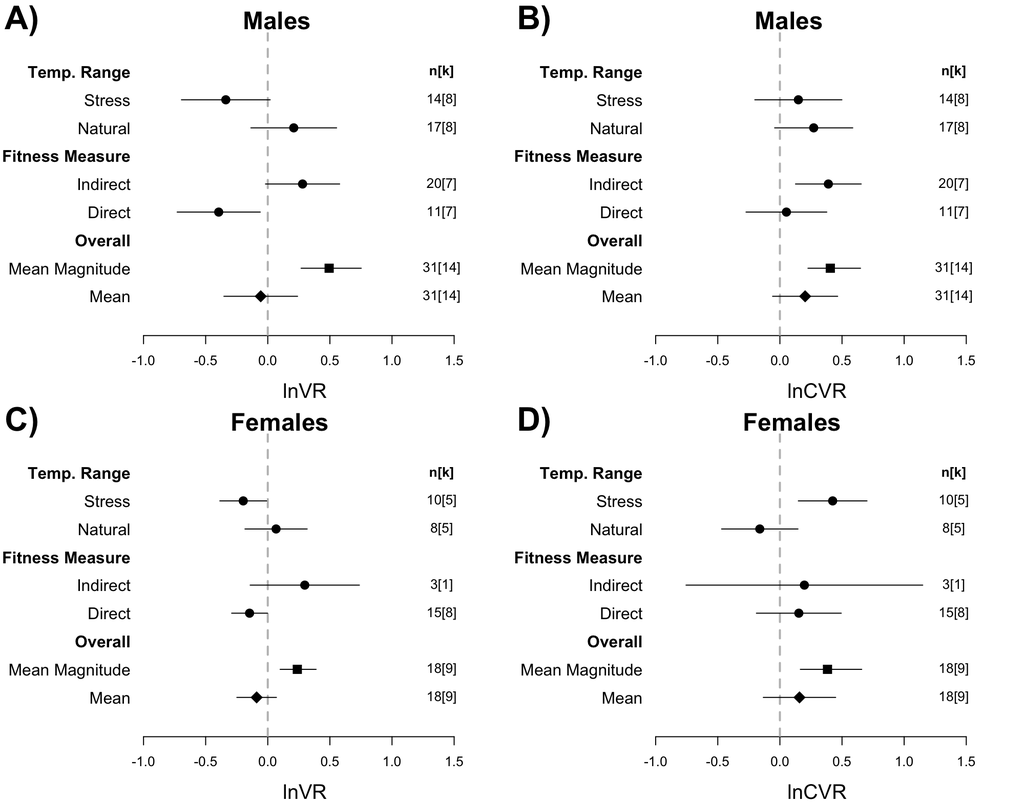

```r
      # Lets make a plot
#pdf(file= "fig1.pdf", height = 8.15859, width =  10.41410)
      par(mar=c(4,8,2,2), mfrow = c(2,2))

      # Males - lnVR
      plot(location_y ~ mean_mag, data = lnVR_males_ests, bty="n", xlim = c(-1, 1.6), ylab = "", xlab = "lnVR", yaxt = "n", pch = c(18,15,16, 16, 16, 16), cex = c(2, rep(1.5, 5)), ylim = c(0, 10), cex.lab = 1.5)
      abline(v = 0, lty = 2, col = "gray", lwd = 2)
      mtext("Males", font = 2, side=3, adj = 0.4, cex = 1.5)
      mtext("A)", font = 2, side=3, adj = -0.4, cex = 2)
      arrows(x0=lnVR_males_ests$mean_mag, y0=lnVR_males_ests$location_y, x1=lnVR_males_ests$L_CI, y1=lnVR_males_ests$location_y, length = 0)
      arrows(x0=lnVR_males_ests$mean_mag, y0=lnVR_males_ests$location_y, x1=lnVR_males_ests$U_CI, y1=lnVR_males_ests$location_y, length = 0)

      nk <- paste0(lnVR_males_ests[,"n"], "[", lnVR_males_ests[,"k"], "]")
      text(nk, y = lnVR_males_ests$location_y, x = 1.4)
      text("n[k]", y = 9, x = 1.4, font = 2)

      Labels <- c("Mean", "Mean Magnitude", "Direct", "Indirect", "Natural", "Stress")
      mtext(Labels, at = lnVR_males_ests$location_y, side = 2, las = 1)
      Headers <- c("Overall", "Fitness Measure", "Temp. Range")
      mtext(Headers, at = c(3, 6, 9), side = 2, las = 1, font = 2)

      # Males - lnCVR
       plot(location_y ~ mean_mag, data = lnCVR_males_ests, bty="n", xlim = c(-1, 1.6), ylab = "", xlab = "lnCVR", yaxt = "n", pch = c(18,15,16, 16, 16, 16), cex = c(2, rep(1.5, 5)), ylim = c(0, 10),cex.lab = 1.5)
      abline(v = 0, lty = 2, col = "gray", lwd = 2)
      mtext("Males", font = 2, side=3, adj = 0.4, cex = 1.5)
      mtext("B)", font = 2, side=3, adj = -0.4, cex = 2)
      arrows(x0=lnCVR_males_ests$mean_mag, y0=lnCVR_males_ests$location_y, x1=lnCVR_males_ests$L_CI, y1=lnCVR_males_ests$location_y, length = 0)
      arrows(x0=lnCVR_males_ests$mean_mag, y0=lnCVR_males_ests$location_y, x1=lnCVR_males_ests$U_CI, y1=lnCVR_males_ests$location_y, length = 0)

      nk <- paste0(lnCVR_males_ests[,"n"], "[", lnCVR_males_ests[,"k"], "]")
      text(nk, y = lnCVR_males_ests$location_y, x = 1.4)
      text("n[k]", y = 9, x = 1.4, font = 2)

      Labels <- c("Mean", "Mean Magnitude", "Direct", "Indirect", "Natural", "Stress")
      mtext(Labels, at = lnCVR_males_ests$location_y, side = 2, las = 1)
      Headers <- c("Overall", "Fitness Measure", "Temp. Range")
      mtext(Headers, at = c(3, 6, 9), side = 2, las = 1, font = 2)

      # Females - lnVR

      plot(location_y ~ mean_mag, data = lnVR_females_ests, bty="n", xlim = c(-1, 1.6), ylab = "", xlab = "lnVR", yaxt = "n", pch = c(18,15,16, 16, 16, 16), cex = c(2, rep(1.5, 5)), ylim = c(0, 10), cex.lab = 1.5)
      abline(v = 0, lty = 2, col = "gray", lwd = 2)
      mtext("Females", font = 2, side=3, adj = 0.4, cex = 1.5)
      mtext("C)", font = 2, side=3, adj = -0.4, cex = 2)
      arrows(x0=lnVR_females_ests$mean_mag, y0=lnVR_females_ests$location_y, x1=lnVR_females_ests$L_CI, y1=lnVR_females_ests$location_y, length = 0)
      arrows(x0=lnVR_females_ests$mean_mag, y0=lnVR_females_ests$location_y, x1=lnVR_females_ests$U_CI, y1=lnVR_females_ests$location_y, length = 0)

      nk <- paste0(lnVR_females_ests[,"n"], "[", lnVR_females_ests[,"k"], "]")
      text(nk, y = lnVR_females_ests$location_y, x = 1.4)
      text("n[k]", y = 9, x = 1.4, font = 2)

      Labels <- c("Mean", "Mean Magnitude", "Direct", "Indirect", "Natural", "Stress")
      mtext(Labels, at = lnVR_females_ests$location_y, side = 2, las = 1)
      Headers <- c("Overall", "Fitness Measure", "Temp. Range")
      mtext(Headers, at = c(3, 6, 9), side = 2, las = 1, font = 2)

      # Females - lnCVR

      plot(location_y ~ mean_mag, data = lnCVR_females_ests, bty="n", xlim = c(-1, 1.6), ylab = "", xlab = "lnCVR", yaxt = "n", pch = c(18,15,16, 16, 16, 16), cex = c(2, rep(1.5, 5)), ylim = c(0, 10), cex.lab = 1.5)
      abline(v = 0, lty = 2, col = "gray", lwd = 2)
      mtext("Females", font = 2, side=3, adj = 0.4, cex = 1.5)
      mtext("D)", font = 2, side=3, adj = -0.4, cex = 2)
      arrows(x0=lnCVR_females_ests$mean_mag, y0=lnCVR_females_ests$location_y, x1=lnCVR_females_ests$L_CI, y1=lnCVR_females_ests$location_y, length = 0)
      arrows(x0=lnCVR_females_ests$mean_mag, y0=lnCVR_females_ests$location_y, x1=lnCVR_females_ests$U_CI, y1=lnCVR_females_ests$location_y, length = 0)

      nk <- paste0(lnCVR_females_ests[,"n"], "[", lnCVR_females_ests[,"k"], "]")
      text(nk, y = lnCVR_females_ests$location_y, x = 1.4)
      text("n[k]", y = 9, x = 1.4, font = 2)

      Labels <- c("Mean", "Mean Magnitude", "Direct", "Indirect", "Natural", "Stress")
      mtext(Labels, at = lnCVR_females_ests$location_y, side = 2, las = 1)
      Headers <- c("Overall", "Fitness Measure", "Temp. Range")
      mtext(Headers, at = c(3, 6, 9), side = 2, las = 1, font = 2)
```

```r
    #dev.off()
```

**Figure 1** – Meta-analytic means for a temperature treatment difference of 7.5 degrees Celsius across MLMA and MLMR models for the log variance ratio (lnVR) and the log coefficient of variation ratio (lnCVR) for males and females. n = total number of effect sizes, whereas k = the total number of studies. Mean estimates and 95% credible/confidence intervals are provided. Subset analyses exploring the impact of various moderators on lnVR and lnCVR are provided (‘circles’), along with the overall meta-analytic mean (‘diamond’) and the mean magnitude of variance differences between treatments (‘square’).

# 5 Publication Bias

```r
par(mfrow = c(3,2))

# lnRR
funnel(MLMA_male_lnRR, yaxis = "seinv", digits = 2, level = c(0.95, 0.99), main = "Males – lnRR")
funnel(MLMA_female_lnRR, yaxis = "seinv", digits = 2, level = c(0.95, 0.99), main = "Females – lnRR")

#lnVR
funnel(MLMA_male_lnVR, yaxis = "seinv", digits = 2, level = c(0.95, 0.99), main = "Males – lnVR")
funnel(MLMA_female_lnVR, yaxis = "seinv", digits = 2, level = c(0.95, 0.99), main = "Females – lnVR")

#lnCVR
funnel(MLMA_male_lnCVR, yaxis = "seinv", digits = 2, level = c(0.95, 0.99), main = "Males – lnCVR")
funnel(MLMA_female_lnCVR, yaxis = "seinv", digits = 2, level = c(0.95, 0.99), main = "Females – lnCVR")
```

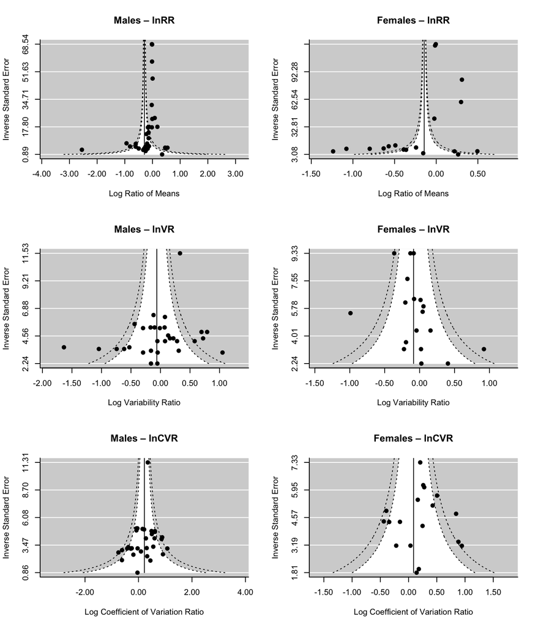

**Figure S1** – Funnel plots of the log response ratio (lnRR), the log variance ratio (lnVR) and log coefficient of variation ratio (lnCVR) as a function of the inverse sampling error for both males and females. Both 95% and 99% pseudo-confidence intervals for sampling variance are provided.

**Conclusions**:There does appear to be some outlying data points and asymmetry in a few plots, but the patterns are not entirely obvious. Publication bias, if it exists, is not entirely clear here, and probably has limited impact on the results. Asymmetry is likely driven more by the limited sample size than actual publication bias.

We can also explore whether there are relationships of the effect sizes with the year of publication to understand whether effects are changing across years. This is unlikely to be the case given that we have so few studies and the empirical work on temperature and sexual selection is rather limited, hence the reason for our synthesis! In any case, we’ll have a look. We will just explore the impact this has in temperature corrected models, so as not to over-parameterize the models too much. Additionally, we will only focus on the mean because there is sound theoretical reasoning to expect a reporting relationship that changes with time on the magnitude of mean changes in temperature. Often, strong mean effect stimulate empirical research into the effects of an experimental manipulation, in the case temperature. At times these are based on strong effects which after corroboration with more empirical research on the topic with larger sample sizes, we begin to see an average decrease in effect sizes as time goes on. So, we expect a negative relationship with year on the mean lnRR:

#### 5.0.0.1 lnRR - Males

```r
  MLMR_male_lnRR_T_year <- metafor::rma.mv(yi ~ deltaT + scale(year), V = vi, random = list( ~1|study, ~1|spp, ~1|obs), data = lnRR_males)
  summary(MLMR_male_lnRR_T_year)
```

```
##
## Multivariate Meta-Analysis Model (k = 31; method: REML)
##
##   logLik  Deviance       AIC       BIC      AICc
## -13.0580   26.1159   38.1159   46.1091   42.1159
##
## Variance Components:
##
##             estim    sqrt  nlvls  fixed  factor
## sigma^2.1  0.5038  0.7098     14     no   study
## sigma^2.2  0.0000  0.0001     11     no     spp
## sigma^2.3  0.0000  0.0000     31     no     obs
##
## Test for Residual Heterogeneity:
## QE(df = 28) = 250.8972, p-val < .0001
##
## Test of Moderators (coefficients 2:3):
## QM(df = 2) = 0.5952, p-val = 0.7426
##
## Model Results:
##
##              estimate      se     zval    pval    ci.lb   ci.ub
## intrcpt       -0.2673  0.1980  -1.3499  0.1770  -0.6553  0.1208
## deltaT         0.0209  0.2744   0.0762  0.9392  -0.5169  0.5587
## scale(year)   -0.1484  0.1946  -0.7625  0.4458  -0.5297  0.2330
##
## ---
## Signif. codes:  0 '***' 0.001 '**' 0.01 '*' 0.05 '.' 0.1 ' ' 1
```

#### 5.0.0.2 lnRR - Females

```r
  MLMR_female_lnRR_T_year <- metafor::rma.mv(yi ~ deltaT + scale(year), V = vi, random = list( ~1|study,  ~1|obs), data = lnRR_females)
  summary(MLMR_female_lnRR_T_year)
```

```
##
## Multivariate Meta-Analysis Model (k = 18; method: REML)
##
##   logLik  Deviance       AIC       BIC      AICc
##  -6.8048   13.6097   23.6097   27.1499   30.2763
##
## Variance Components:
##
##             estim    sqrt  nlvls  fixed  factor
## sigma^2.1  0.2324  0.4820      9     no   study
## sigma^2.2  0.0446  0.2113     18     no     obs
##
## Test for Residual Heterogeneity:
## QE(df = 15) = 339.7540, p-val < .0001
##
## Test of Moderators (coefficients 2:3):
## QM(df = 2) = 1.7779, p-val = 0.4111
##
## Model Results:
##
##              estimate      se     zval    pval    ci.lb   ci.ub
## intrcpt       -0.2087  0.1751  -1.1919  0.2333  -0.5519  0.1345
## deltaT         0.1615  0.1340   1.2048  0.2283  -0.1012  0.4242
## scale(year)   -0.1812  0.1957  -0.9261  0.3544  -0.5647  0.2023
##
## ---
## Signif. codes:  0 '***' 0.001 '**' 0.01 '*' 0.05 '.' 0.1 ' ' 1
```

**Conclusions**: We do indeed see evidence for a negative relationship on mean lnRR over time for both males and females, but this is not significant. As more studies accumulate we might expect to see this relationship to become stronger.

# 6 Sensitivity Analyses

In this section we’ll explore the impact of some of the assumptions made when extracting and calculating the effect sizes on the inferences drawn from the analyses. Our ability to account for everything is fairly limited given the small sample sizes as so few studies experimentally manipulate temperatures in the context of sexual selection. In any case, we should explore how they impact our inferences as best as we can.

### 6.0.1 Phylogeny

We can have a look at finding a somewhat resolved phylogenetic tree of the taxa using the open tree of life. Trying time tree, there are too many unresolved taxa. To start, we need to first get the unique list of taxa in our data. We’ll do this for the entire dataset and then we can prune the tree should we need to do this.

```r
    spp_names <- unique(data$spp)

    # Search rotl
      tl <- tnrs_match_names(spp_names)

    # Generate the tree with the list of ott_ids
      tree_tmp <- tol_induced_subtree(ott_ids=tl$ott_id)
```

```
##
Progress [---------------------------------] 0/245 (  0) ?s
Progress [==============================] 245/245 (100)  0s
```

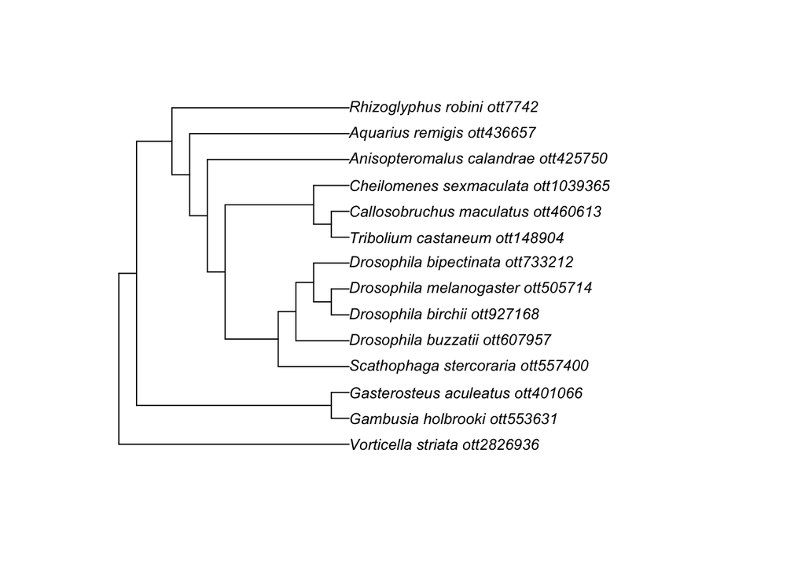

```r
    # Have a look
      plot(tree_tmp, cex = 0.8)
```

```r
  ott_id <- tl$ott_id

  # Add in the correct id for Drosophila and Phorticella
    ott_id[c(12, 10)] <- c("505714", "4420733")

    # Generate the tree with the list of ott_ids
      tree <- tol_induced_subtree(ott_ids=ott_id)
```

```
##
Progress [---------------------------------] 0/223 (  0) ?s
Progress [==============================] 223/223 (100)  0s
```

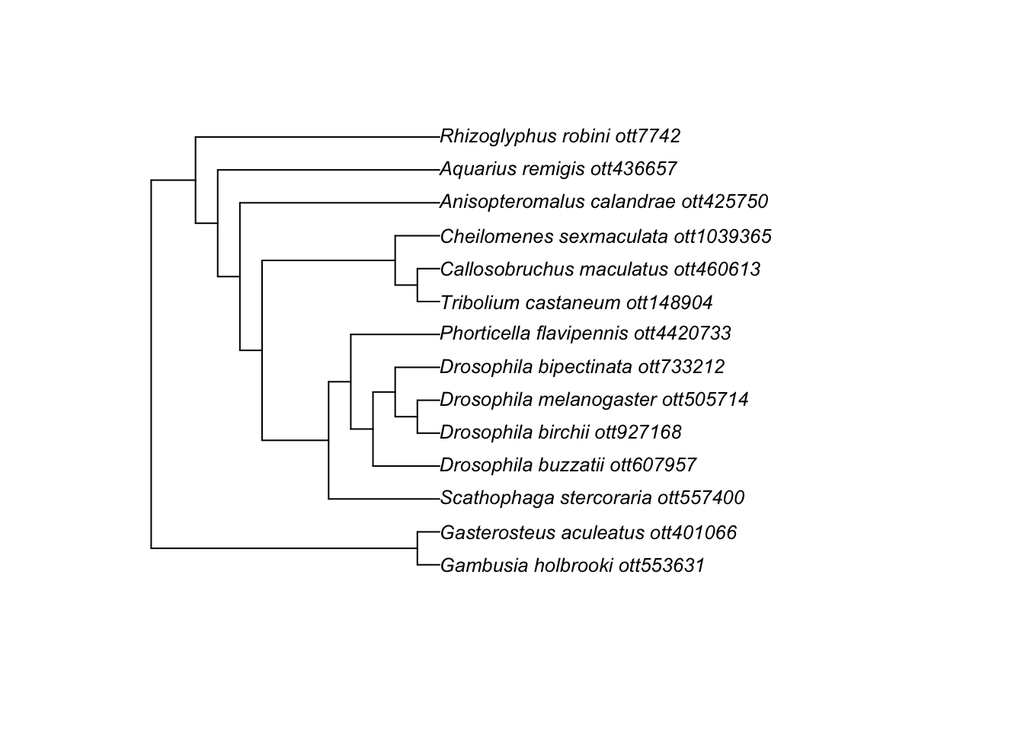

```r
    # Have a look
      plot(tree, cex = 0.8)
```

OK, now it looks more sensible. The taxa are placed into what looks to be about their correct taxonomic positions. Note that for *Phorticella striata* we used a different, and presumably closely related species *Phorticella flavipennes* given the other species was not identified in an online search. But, this is a Drosophlid like species and so its taxonomic position is correct within the tree. We will use this tree to attempt to understand whether there is evidence for a phylogenetic signal in these data:

```r
  phylo_branch <- compute.brlen(tree, method = "Grafen", power = 0.5)
  phylo_branch$tip.label <- gsub("_ott[0-9]+", "", phylo_branch$tip.label)

  # Prune male tree
        lnCVR_males$spp <- ifelse(lnCVR_males$spp == "Phorticella_striata", "Phorticella_flavipennis", lnCVR_males$spp)
        lnVR_males$spp <- ifelse(lnVR_males$spp == "Phorticella_striata", "Phorticella_flavipennis", lnVR_males$spp)
      male_tree <- drop.tip(phylo_branch, phylo_branch$tip.label[-match(unique(lnCVR_males$spp), phylo_branch$tip.label)])

  # Prune female tree
         lnVR_females$spp <-   ifelse(lnVR_females$spp == "Menochilus_sexmaculatus", "Cheilomenes_sexmaculata", lnVR_females$spp)
        lnCVR_females$spp <-   ifelse(lnCVR_females$spp == "Menochilus_sexmaculatus", "Cheilomenes_sexmaculata", lnCVR_females$spp)

  # Fix a spelling mistake
         lnVR_females$spp <-   ifelse(lnVR_females$spp == "Tribolium_castneum", "Tribolium_castaneum", lnVR_females$spp)
        lnCVR_females$spp <-   ifelse(lnCVR_females$spp == "Tribolium_castneum", "Tribolium_castaneum", lnCVR_females$spp)

        female_tree <- drop.tip(phylo_branch, phylo_branch$tip.label[-match(unique(lnCVR_females$spp), phylo_branch$tip.label)])

  # Check trees are ultrametric
  is.ultrametric(male_tree)
```

```
## [1] TRUE
```

```r
  is.ultrametric(female_tree)
```

```
## [1] TRUE
```

```r
  # Phylogenetic correlation matrix.
    P_males <- vcv(male_tree, model="Brownian", corr = TRUE)
  P_females <- vcv(female_tree, model="Brownian", corr = TRUE)
```

We can plot the subset of taxa for each sex. For the males we have the following tree:

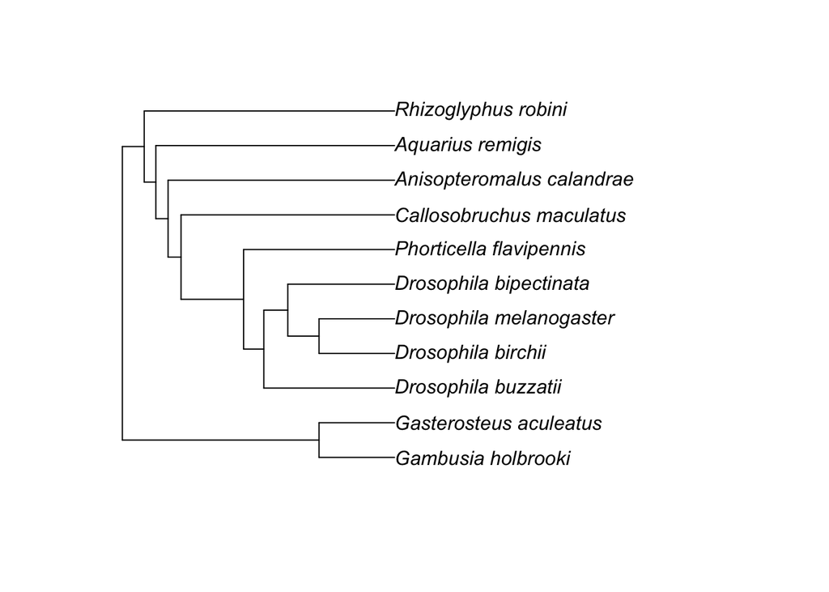

```r
  plot(male_tree)
```

**Figure S2** – Phylogenetic tree (tree topology) used to control for non-independence among taxa in our male dataset.

and for the females, we have the following tree:

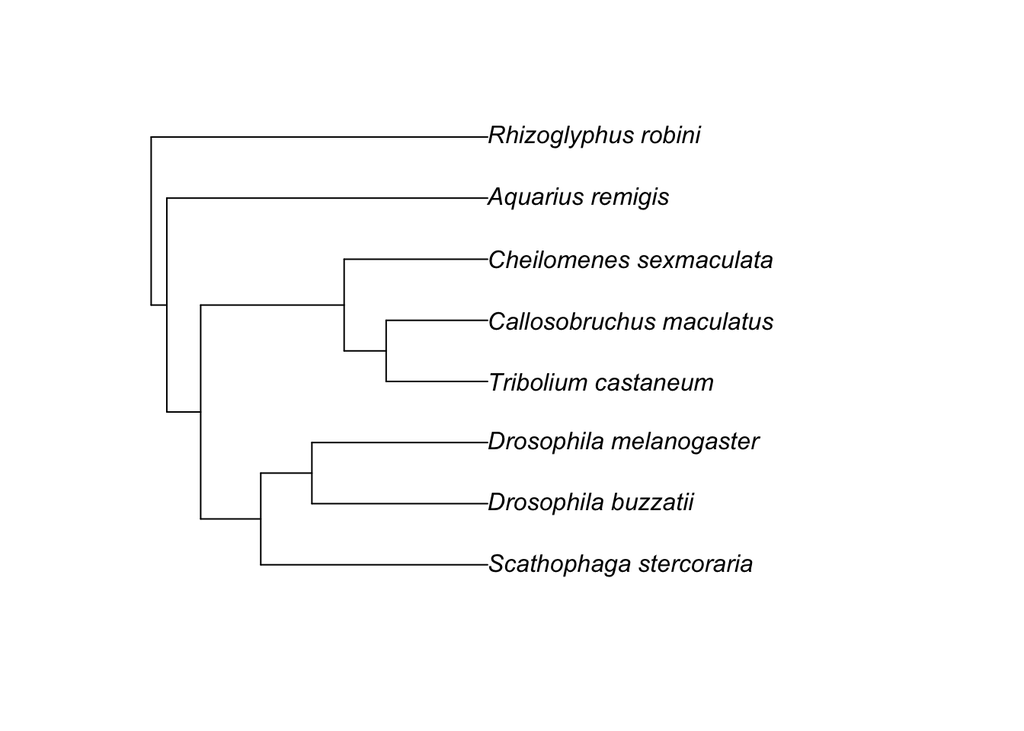

```r
  plot(female_tree)
```

**Figure S3** – Phylogenetic tree (tree topology) used to control for non-independence among taxa in our female dataset.

Now that we have the phylogenies we can re-run a few models including the correlation structure. We’ll do males, and then females:

```r
  # Males
  MLMA_male_lnVR_phylo <- metafor::rma.mv(yi ~ 1, V = vi, random = list( ~1|study, ~1|spp, ~1|obs), R = list(spp = P_males), data = lnVR_males)
  summary(MLMA_male_lnVR_phylo)
```

```
##
## Multivariate Meta-Analysis Model (k = 31; method: REML)
##
##   logLik  Deviance       AIC       BIC      AICc
## -19.1939   38.3878   46.3878   51.9926   47.9878
##
## Variance Components:
##
##             estim    sqrt  nlvls  fixed  factor    R
## sigma^2.1  0.2587  0.5086     14     no   study   no
## sigma^2.2  0.0000  0.0000     11     no     spp  yes
## sigma^2.3  0.0212  0.1457     31     no     obs   no
##
## Test for Heterogeneity:
## Q(df = 30) = 144.0839, p-val < .0001
##
## Model Results:
##
## estimate      se     zval    pval    ci.lb   ci.ub
##  -0.0627  0.1479  -0.4240  0.6716  -0.3526  0.2272
##
## ---
## Signif. codes:  0 '***' 0.001 '**' 0.01 '*' 0.05 '.' 0.1 ' ' 1
```

```r
  MLMA_male_lnCVR_phylo <- metafor::rma.mv(yi ~ 1, V = vi, random = list( ~1|study, ~1|spp, ~1|obs), R = list(spp = P_males), data = lnCVR_males)
  summary(MLMA_male_lnCVR_phylo)
```

```
##
## Multivariate Meta-Analysis Model (k = 31; method: REML)
##
##   logLik  Deviance       AIC       BIC      AICc
## -18.3405   36.6810   44.6810   50.2858   46.2810
##
## Variance Components:
##
##             estim    sqrt  nlvls  fixed  factor    R
## sigma^2.1  0.0815  0.2855     14     no   study   no
## sigma^2.2  0.0382  0.1954     11     no     spp  yes
## sigma^2.3  0.0233  0.1526     31     no     obs   no
##
## Test for Heterogeneity:
## Q(df = 30) = 77.8102, p-val < .0001
##
## Model Results:
##
## estimate      se    zval    pval    ci.lb   ci.ub
##   0.2534  0.1423  1.7810  0.0749  -0.0255  0.5323  .
##
## ---
## Signif. codes:  0 '***' 0.001 '**' 0.01 '*' 0.05 '.' 0.1 ' ' 1
```

```r
  #Females
MLMA_female_lnVR_phylo <- metafor::rma.mv(yi ~ 1, V = vi, random = list( ~1|study, ~1|spp, ~1|obs), R = list(spp = P_females), data = lnVR_females)
  summary(MLMA_female_lnVR_phylo)
```

```
##
## Multivariate Meta-Analysis Model (k = 18; method: REML)
##
##   logLik  Deviance       AIC       BIC      AICc
##  -6.1436   12.2872   20.2872   23.6201   23.6206
##
## Variance Components:
##
##             estim    sqrt  nlvls  fixed  factor    R
## sigma^2.1  0.0000  0.0000      9     no   study   no
## sigma^2.2  0.0174  0.1319      8     no     spp  yes
## sigma^2.3  0.0482  0.2196     18     no     obs   no
##
## Test for Heterogeneity:
## Q(df = 17) = 45.0805, p-val = 0.0002
##
## Model Results:
##
## estimate      se     zval    pval    ci.lb   ci.ub
##  -0.0952  0.0977  -0.9745  0.3298  -0.2866  0.0963
##
## ---
## Signif. codes:  0 '***' 0.001 '**' 0.01 '*' 0.05 '.' 0.1 ' ' 1
```

```r
MLMA_female_lnCVR_phylo <- metafor::rma.mv(yi ~ 1, V = vi, random = list( ~1|study, ~1|spp, ~1|obs), R = list(spp = P_females), data = lnCVR_females)
  summary(MLMA_female_lnCVR_phylo)
```

```
##
## Multivariate Meta-Analysis Model (k = 18; method: REML)
##
##   logLik  Deviance       AIC       BIC      AICc
##  -7.6917   15.3835   23.3835   26.7163   26.7168
##
## Variance Components:
##
##             estim    sqrt  nlvls  fixed  factor    R
## sigma^2.1  0.1452  0.3810      9     no   study   no
## sigma^2.2  0.0000  0.0000      8     no     spp  yes
## sigma^2.3  0.0000  0.0000     18     no     obs   no
##
## Test for Heterogeneity:
## Q(df = 17) = 51.1258, p-val < .0001
##
## Model Results:
##
## estimate      se    zval    pval    ci.lb   ci.ub
##   0.1494  0.1434  1.0418  0.2975  -0.1317  0.4305
##
## ---
## Signif. codes:  0 '***' 0.001 '**' 0.01 '*' 0.05 '.' 0.1 ' ' 1
```

We can see from the above, controlling for tree topology doesn’t change the results much at all.

### 6.0.2 Effect sizes derived from proportions

Much of the literature currently reports data as proportions, average and some measure of error. We are well aware that proportion data is not normally distributed as its bound between 0 and 1, however, when reported as an average it does have error and so long as its not “extreme” (i.e., close to 0 and 1), should behave as though it is normal. Nonetheless, this may affect conclusions and so we test if there were significant differences between effect sizes generated with proportion data after temperature correction. This is expected to have potentially stronger effects on variance so we will stick to our main analyses:

```r
  # Males
  MLMA_male_lnVR_prop <- metafor::rma.mv(yi ~ 1 + deltaT + prop, V = vi, random = list( ~1|study, ~1|spp, ~1|obs), data = lnVR_males)
  summary(MLMA_male_lnVR_prop)
```

```
##
## Multivariate Meta-Analysis Model (k = 31; method: REML)
##
##   logLik  Deviance       AIC       BIC      AICc
## -17.7090   35.4179   47.4179   55.4111   51.4179
##
## Variance Components:
##
##             estim    sqrt  nlvls  fixed  factor
## sigma^2.1  0.2790  0.5282     14     no   study
## sigma^2.2  0.0000  0.0001     11     no     spp
## sigma^2.3  0.0246  0.1569     31     no     obs
##
## Test for Residual Heterogeneity:
## QE(df = 28) = 131.2961, p-val < .0001
##
## Test of Moderators (coefficients 2:3):
## QM(df = 2) = 0.5432, p-val = 0.7621
##
## Model Results:
##
##          estimate      se     zval    pval    ci.lb   ci.ub
## intrcpt   -0.0382  0.1687  -0.2266  0.8207  -0.3688  0.2924
## deltaT     0.1507  0.2153   0.7000  0.4839  -0.2712  0.5726
## prop      -0.0714  0.2617  -0.2730  0.7848  -0.5843  0.4415
##
## ---
## Signif. codes:  0 '***' 0.001 '**' 0.01 '*' 0.05 '.' 0.1 ' ' 1
```

```r
  MLMA_male_lnCVR_prop <- metafor::rma.mv(yi ~ 1 + deltaT + prop, V = vi, random = list( ~1|study, ~1|spp, ~1|obs), data = lnCVR_males)
  summary(MLMA_male_lnCVR_prop)
```

```
##
## Multivariate Meta-Analysis Model (k = 31; method: REML)
##
##   logLik  Deviance       AIC       BIC      AICc
## -15.9079   31.8158   43.8158   51.8090   47.8158
##
## Variance Components:
##
##             estim    sqrt  nlvls  fixed  factor
## sigma^2.1  0.0569  0.2386     14     no   study
## sigma^2.2  0.0000  0.0000     11     no     spp
## sigma^2.3  0.0383  0.1957     31     no     obs
##
## Test for Residual Heterogeneity:
## QE(df = 28) = 62.2306, p-val = 0.0002
##
## Test of Moderators (coefficients 2:3):
## QM(df = 2) = 4.7095, p-val = 0.0949
##
## Model Results:
##
##          estimate      se     zval    pval    ci.lb   ci.ub
## intrcpt    0.3596  0.1090   3.2994  0.0010   0.1460  0.5732  ***
## deltaT     0.1549  0.1227   1.2621  0.2069  -0.0856  0.3953
## prop      -0.4140  0.2143  -1.9321  0.0534  -0.8339  0.0060    .
##
## ---
## Signif. codes:  0 '***' 0.001 '**' 0.01 '*' 0.05 '.' 0.1 ' ' 1
```

```r
  #Females
MLMA_female_lnVR_prop <- metafor::rma.mv(yi ~ 1 +deltaT + prop, V = vi, random = list( ~1|study, ~1|spp, ~1|obs), R = list(spp = P_females), data = lnVR_females)
  summary(MLMA_female_lnVR_prop)
```

```
##
## Multivariate Meta-Analysis Model (k = 18; method: REML)
##
##   logLik  Deviance       AIC       BIC      AICc
##  -5.4666   10.9333   22.9333   27.1816   33.4333
##
## Variance Components:
##
##             estim    sqrt  nlvls  fixed  factor    R
## sigma^2.1  0.0000  0.0000      9     no   study   no
## sigma^2.2  0.0140  0.1185      8     no     spp  yes
## sigma^2.3  0.0518  0.2277     18     no     obs   no
##
## Test for Residual Heterogeneity:
## QE(df = 15) = 39.4920, p-val = 0.0005
##
## Test of Moderators (coefficients 2:3):
## QM(df = 2) = 1.6333, p-val = 0.4419
##
## Model Results:
##
##          estimate      se     zval    pval    ci.lb   ci.ub
## intrcpt   -0.1205  0.0992  -1.2150  0.2244  -0.3150  0.0739
## deltaT     0.0506  0.0613   0.8261  0.4087  -0.0695  0.1708
## prop       0.2363  0.2522   0.9367  0.3489  -0.2581  0.7307
##
## ---
## Signif. codes:  0 '***' 0.001 '**' 0.01 '*' 0.05 '.' 0.1 ' ' 1
```

```r
MLMA_female_lnCVR_prop <- metafor::rma.mv(yi ~ 1 + deltaT + prop, V = vi, random = list( ~1|study, ~1|spp, ~1|obs), R = list(spp = P_females), data = lnCVR_females)
  summary(MLMA_female_lnCVR_prop)
```

```
##
## Multivariate Meta-Analysis Model (k = 18; method: REML)
##
##   logLik  Deviance       AIC       BIC      AICc
##  -6.0200   12.0400   24.0400   28.2883   34.5400
##
## Variance Components:
##
##             estim    sqrt  nlvls  fixed  factor    R
## sigma^2.1  0.1470  0.3834      9     no   study   no
## sigma^2.2  0.0000  0.0000      8     no     spp  yes
## sigma^2.3  0.0000  0.0000     18     no     obs   no
##
## Test for Residual Heterogeneity:
## QE(df = 15) = 39.4823, p-val = 0.0005
##
## Test of Moderators (coefficients 2:3):
## QM(df = 2) = 1.7371, p-val = 0.4196
##
## Model Results:
##
##          estimate      se     zval    pval    ci.lb   ci.ub
## intrcpt    0.2302  0.1592   1.4459  0.1482  -0.0819  0.5423
## deltaT    -0.0763  0.1043  -0.7315  0.4645  -0.2807  0.1281
## prop      -0.4105  0.3776  -1.0872  0.2770  -1.1506  0.3296
##
## ---
## Signif. codes:  0 '***' 0.001 '**' 0.01 '*' 0.05 '.' 0.1 ' ' 1
```

**Conclusion**: There appears to be a slight difference between effect sizes generated with proportion data for male lnCVR where they had a smaller CV relative to other non-proportion traits. While this is not significant, it’s worth controlling for this in models.

Just to be safe, and although our models are getting heavy on the parameters, we will also explore how accounting for these different types of effect sizes affect the inferences drawn for lnVR and lnCVR, the effects most of interest to us:

#### 6.0.2.1 lnVR - Males - Fitness

```r
  MLMR_male_lnVR_T_Fitness <- metafor::rma.mv(yi ~ -1 + deltaT+ prop +fitness, V = vi, random = list( ~1|study, ~1|spp, ~1|obs), data = lnVR_males)
  summary(MLMR_male_lnVR_T_Fitness)
```

```
##
## Multivariate Meta-Analysis Model (k = 31; method: REML)
##
##   logLik  Deviance       AIC       BIC      AICc
## -14.0443   28.0885   42.0885   51.1594   47.9833
##
## Variance Components:
##
##             estim    sqrt  nlvls  fixed  factor
## sigma^2.1  0.1273  0.3568     14     no   study
## sigma^2.2  0.0140  0.1183     11     no     spp
## sigma^2.3  0.0271  0.1647     31     no     obs
##
## Test for Residual Heterogeneity:
## QE(df = 27) = 85.9034, p-val < .0001
##
## Test of Moderators (coefficients 1:4):
## QM(df = 4) = 9.5252, p-val = 0.0492
##
## Model Results:
##
##                  estimate      se     zval    pval    ci.lb    ci.ub
## deltaT             0.1271  0.1614   0.7875  0.4310  -0.1892   0.4434
## prop               0.0770  0.2378   0.3240  0.7460  -0.3890   0.5431
## fitnessdirect     -0.4340  0.2062  -2.1048  0.0353  -0.8381  -0.0299  *
## fitnessindirect    0.2658  0.1620   1.6408  0.1008  -0.0517   0.5832
##
## ---
## Signif. codes:  0 '***' 0.001 '**' 0.01 '*' 0.05 '.' 0.1 ' ' 1
```

#### 6.0.2.2 lnCVR - Males - Fitness

```r
  MLMR_male_lnCVR_T_Fitness <- metafor::rma.mv(yi ~ -1+deltaT+ prop +fitness, V = vi, random = list( ~1|study, ~1|spp, ~1|obs), data = lnCVR_males)
  summary(MLMR_male_lnCVR_T_Fitness)
```

```
##
## Multivariate Meta-Analysis Model (k = 31; method: REML)
##
##   logLik  Deviance       AIC       BIC      AICc
## -15.0884   30.1769   44.1769   53.2477   50.0716
##
## Variance Components:
##
##             estim    sqrt  nlvls  fixed  factor
## sigma^2.1  0.0693  0.2632     14     no   study
## sigma^2.2  0.0000  0.0000     11     no     spp
## sigma^2.3  0.0301  0.1734     31     no     obs
##
## Test for Residual Heterogeneity:
## QE(df = 27) = 60.4983, p-val = 0.0002
##
## Test of Moderators (coefficients 1:4):
## QM(df = 4) = 11.9607, p-val = 0.0176
##
## Model Results:
##
##                  estimate      se     zval    pval    ci.lb   ci.ub
## deltaT             0.1365  0.1283   1.0644  0.2871  -0.1149  0.3879
## prop              -0.3150  0.2367  -1.3310  0.1832  -0.7789  0.1489
## fitnessdirect      0.1939  0.1906   1.0173  0.3090  -0.1797  0.5674
## fitnessindirect    0.4254  0.1279   3.3261  0.0009   0.1747  0.6761  ***
##
## ---
## Signif. codes:  0 '***' 0.001 '**' 0.01 '*' 0.05 '.' 0.1 ' ' 1
```

#### 6.0.2.3 lnVR - Males - Stress

```r
  MLMR_male_lnVR_T_stress <- metafor::rma.mv(yi ~ -1 + deltaT+prop +temp.range, V = vi, random = list( ~1|study, ~1|spp, ~1|obs), data = lnVR_males)
  summary(MLMR_male_lnVR_T_stress)
```

```
##
## Multivariate Meta-Analysis Model (k = 31; method: REML)
##
##   logLik  Deviance       AIC       BIC      AICc
## -14.6031   29.2062   43.2062   52.2770   49.1009
##
## Variance Components:
##
##             estim    sqrt  nlvls  fixed  factor
## sigma^2.1  0.2385  0.4884     14     no   study
## sigma^2.2  0.0000  0.0000     11     no     spp
## sigma^2.3  0.0140  0.1185     31     no     obs
##
## Test for Residual Heterogeneity:
## QE(df = 27) = 104.9595, p-val < .0001
##
## Test of Moderators (coefficients 1:4):
## QM(df = 4) = 6.3729, p-val = 0.1730
##
## Model Results:
##
##                    estimate      se     zval    pval    ci.lb   ci.ub
## deltaT               0.0888  0.2004   0.4430  0.6578  -0.3040  0.4816
## prop                 0.0053  0.2474   0.0213  0.9830  -0.4796  0.4901
## temp.rangenatural    0.2073  0.1871   1.1080  0.2679  -0.1594  0.5740
## temp.rangestress    -0.3412  0.2032  -1.6790  0.0931  -0.7395  0.0571  .
##
## ---
## Signif. codes:  0 '***' 0.001 '**' 0.01 '*' 0.05 '.' 0.1 ' ' 1
```

#### 6.0.2.4 lnCVR - Males - Stress

```r
  MLMR_male_lnCVR_T_stress <- metafor::rma.mv(yi ~ -1 + deltaT+prop +temp.range, V = vi, random = list( ~1|study, ~1|spp, ~1|obs), data = lnCVR_males)
  summary(MLMR_male_lnCVR_T_stress)
```

```
##
## Multivariate Meta-Analysis Model (k = 31; method: REML)
##
##   logLik  Deviance       AIC       BIC      AICc
## -15.6682   31.3364   45.3364   54.4072   51.2311
##
## Variance Components:
##
##             estim    sqrt  nlvls  fixed  factor
## sigma^2.1  0.0751  0.2740     14     no   study
## sigma^2.2  0.0000  0.0000     11     no     spp
## sigma^2.3  0.0360  0.1896     31     no     obs
##
## Test for Residual Heterogeneity:
## QE(df = 27) = 61.8668, p-val = 0.0001
##
## Test of Moderators (coefficients 1:4):
## QM(df = 4) = 9.9632, p-val = 0.0411
##
## Model Results:
##
##                    estimate      se     zval    pval    ci.lb   ci.ub
## deltaT               0.1483  0.1341   1.1059  0.2688  -0.1145  0.4111
## prop                -0.4020  0.2312  -1.7389  0.0821  -0.8551  0.0511   .
## temp.rangenatural    0.3669  0.1411   2.6010  0.0093   0.0904  0.6434  **
## temp.rangestress     0.3477  0.1631   2.1325  0.0330   0.0281  0.6673   *
##
## ---
## Signif. codes:  0 '***' 0.001 '**' 0.01 '*' 0.05 '.' 0.1 ' ' 1
```

#### 6.0.2.5 lnVR - Females - Fitness

```r
  MLMR_female_lnVR_T_Fitness <- metafor::rma.mv(yi ~ -1+ deltaT+ prop +fitness, V = vi, random = list( ~1|study,  ~1|obs), data = lnVR_females)
  summary(MLMR_female_lnVR_T_Fitness)
```

```
##
## Multivariate Meta-Analysis Model (k = 18; method: REML)
##
##   logLik  Deviance       AIC       BIC      AICc
##  -3.7321    7.4643   19.4643   23.2986   31.4643
##
## Variance Components:
##
##             estim    sqrt  nlvls  fixed  factor
## sigma^2.1  0.0000  0.0000      9     no   study
## sigma^2.2  0.0456  0.2137     18     no     obs
##
## Test for Residual Heterogeneity:
## QE(df = 14) = 33.4092, p-val = 0.0025
##
## Test of Moderators (coefficients 1:4):
## QM(df = 4) = 8.6602, p-val = 0.0702
##
## Model Results:
##
##                  estimate      se     zval    pval    ci.lb    ci.ub
## deltaT             0.0783  0.0548   1.4284  0.1532  -0.0291   0.1858
## prop               0.2837  0.2288   1.2397  0.2151  -0.1648   0.7322
## fitnessdirect     -0.1794  0.0779  -2.3023  0.0213  -0.3321  -0.0267  *
## fitnessindirect    0.2965  0.2240   1.3239  0.1855  -0.1425   0.7355
##
## ---
## Signif. codes:  0 '***' 0.001 '**' 0.01 '*' 0.05 '.' 0.1 ' ' 1
```

#### 6.0.2.6 lnCVR - Females - Fitness

```r
  MLMR_female_lnCVR_T_Fitness <- metafor::rma.mv(yi ~ -1 + deltaT+ prop + fitness, V = vi, random = list( ~1|study,  ~1|obs), data = lnCVR_females)
  summary(MLMR_female_lnCVR_T_Fitness)
```

```
##
## Multivariate Meta-Analysis Model (k = 18; method: REML)
##
##   logLik  Deviance       AIC       BIC      AICc
##  -5.3956   10.7913   22.7913   26.6256   34.7913
##
## Variance Components:
##
##             estim    sqrt  nlvls  fixed  factor
## sigma^2.1  0.1917  0.4378      9     no   study
## sigma^2.2  0.0000  0.0000     18     no     obs
##
## Test for Residual Heterogeneity:
## QE(df = 14) = 39.3971, p-val = 0.0003
##
## Test of Moderators (coefficients 1:4):
## QM(df = 4) = 2.2513, p-val = 0.6896
##
## Model Results:
##
##                  estimate      se     zval    pval    ci.lb   ci.ub
## deltaT            -0.0776  0.1200  -0.6472  0.5175  -0.3128  0.1575
## prop              -0.4102  0.4211  -0.9742  0.3300  -1.2355  0.4151
## fitnessdirect      0.2385  0.1942   1.2279  0.2195  -0.1422  0.6191
## fitnessindirect    0.1947  0.4825   0.4035  0.6866  -0.7510  1.1404
##
## ---
## Signif. codes:  0 '***' 0.001 '**' 0.01 '*' 0.05 '.' 0.1 ' ' 1
```

#### 6.0.2.7 lnVR - Females - Stress

```r
  MLMR_female_lnVR_T_stress <- metafor::rma.mv(yi ~ -1 + deltaT+ prop + temp.range, V = vi, random = list( ~1|study, ~1|obs), data = lnVR_females)
  summary(MLMR_female_lnVR_T_stress)
```

```
##
## Multivariate Meta-Analysis Model (k = 18; method: REML)
##
##   logLik  Deviance       AIC       BIC      AICc
##  -4.7937    9.5874   21.5874   25.4218   33.5874
##
## Variance Components:
##
##             estim    sqrt  nlvls  fixed  factor
## sigma^2.1  0.0000  0.0000      9     no   study
## sigma^2.2  0.0611  0.2471     18     no     obs
##
## Test for Residual Heterogeneity:
## QE(df = 14) = 37.2866, p-val = 0.0007
##
## Test of Moderators (coefficients 1:4):
## QM(df = 4) = 5.4681, p-val = 0.2425
##
## Model Results:
##
##                    estimate      se     zval    pval    ci.lb    ci.ub
## deltaT               0.0255  0.0629   0.4049  0.6856  -0.0979   0.1488
## prop                 0.1272  0.2576   0.4938  0.6214  -0.3776   0.6320
## temp.rangenatural    0.0383  0.1454   0.2635  0.7922  -0.2467   0.3233
## temp.rangestress    -0.2013  0.0994  -2.0263  0.0427  -0.3961  -0.0066  *
##
## ---
## Signif. codes:  0 '***' 0.001 '**' 0.01 '*' 0.05 '.' 0.1 ' ' 1
```

#### 6.0.2.8 lnCVR - Females - Stress

```r
  MLMR_female_lnCVR_T_stress <- metafor::rma.mv(yi ~ -1+deltaT+prop +temp.range, V = vi, random = list( ~1|study,  ~1|obs), data = lnCVR_females)
  summary(MLMR_female_lnCVR_T_stress)
```

```
##
## Multivariate Meta-Analysis Model (k = 18; method: REML)
##
##   logLik  Deviance       AIC       BIC      AICc
##  -3.7212    7.4424   19.4424   23.2768   31.4424
##
## Variance Components:
##
##             estim    sqrt  nlvls  fixed  factor
## sigma^2.1  0.0646  0.2541      9     no   study
## sigma^2.2  0.0000  0.0000     18     no     obs
##
## Test for Residual Heterogeneity:
## QE(df = 14) = 27.4320, p-val = 0.0169
##
## Test of Moderators (coefficients 1:4):
## QM(df = 4) = 10.7994, p-val = 0.0289
##
## Model Results:
##
##                    estimate      se     zval    pval    ci.lb   ci.ub
## deltaT              -0.0179  0.0801  -0.2235  0.8231  -0.1749  0.1391
## prop                -0.2231  0.3090  -0.7219  0.4703  -0.8288  0.3826
## temp.rangenatural   -0.1008  0.1816  -0.5553  0.5787  -0.4567  0.2550
## temp.rangestress     0.4377  0.1467   2.9833  0.0029   0.1501  0.7252  **
##
## ---
## Signif. codes:  0 '***' 0.001 '**' 0.01 '*' 0.05 '.' 0.1 ' ' 1
```

**Conclusions**: Across all models, when we account for the slight decrease in variance resulting from effects generated with proportion data we see no changes in any of the main conclusions.

### 6.0.3 Adapted temperatures of the population – A discussion

Upon close reading of the research papers that were included in the meta-analysis, it is clear that study design varies a lot. More specifically, many studies are temperature manipulations on isofemale lines or lab-bred populations that have been bred and reared in the lab for many (sometimes, hundreds) of generations. These lab colonies have different temperature treatments to what would be normally encountered in nature, and to some extent, they are adapted quite well to the constant temperature conditions in which they have been bread. This means that, while temperature may affect the variance, it may also come down to which temperature treatment the population has adapted to with respect to how temperature impacts sexual selection. This means that, the relationship between temperature and its effect on sexual selection is not as simple as a linear relationship between temperature and variation in fitness, but rather it also depends on whether the temperature treatments involve a temperature for which the population is adapted to. Our analysis on the ‘magnitude’ of change in variance across temperatures gets around the above problem, but it may still be important to have a closer inspection of this problem in the future.

Given the limited sample size and the fact that so few studies reported clearly what temperature populations were adapted to (we only really know this for experimental evolution studies), it was unclear how to best deal with this issue other than to acknowledge that it exists. Additionally, it could only be dealt with for a small sample of effect sizes in our dataset. For example, for males, we could only be confident about 12 of 31 effects and only 4 of these involved a temperature that was one of the treatments. For females, we had information about 10 of 18 effects and 4 of these involved a temperature that was one of the treatments. The other treatments varied and/or it was unclear. This is further challenging to deal with given that it is unclear how temperature adaptation itself will impact the variance. We presume that this will decrease phenotypic variance as a result of stabilizing selection, but this assumption is not entirely clear.

### 6.0.4 Trait dependency among effects

Given studies reported, at times, multiple traits – especially when considering indirect estimates as multiple traits were presented that could all be correlated with reproductive success (i.e., sperm motility, fertilization success). While we took the indirect estimate most closely associated with reproductive fitness where possible, at times it was not clear, and so we extracted a couple representative estimates. This induces some level of non-independence among effect sizes and so is something we should attempt to deal with.

For females, all effect sizes were independent samples of individuals. For males, there were approximately 8 effect sizes that were dependent in some form. To account for this non-independence, we can estimate a correlation matrix and include this as the residual level to account for this dependency. Part of the problem here is simply that we don’t know the exact correlation among these effect sizes exactly to properly address this issue, but in all cases these are sperm traits that were done on the same sample and so presumably have a moderate to high correlation with each other. We will assume for now that they have a correlation (on average) of about 0.70 and generate a residual correlation matrix to just simply test this out:

First, lets generate a correlation matrix. Its so few studies that we’ll just do this by hand for now, but there are easier methods for more complicated problems

```r
  # Create a matrix the same size as observations. lnVR and lnCVR are the same in terms of what is dependent, so we can do this with one dataset
  R <- diag(nrow(lnVR_males))
  R[c(8,9), c(9,8)] <- 0.7
  R[c(10,11), c(11,10)] <- 0.7
  R[c(19,20), c(20,19)] <- 0.7
  R[c(21,22), c(22,21)] <- 0.7
  diag(R) <- 1
  rownames(R) <- colnames(R) <- rownames(lnVR_males)
```

Now that we have the matrix with the relevant off-diagonals set to a correlation of 0.7, we can fit this at the residual level to account for non-independence and test if it impacts the inferences drawn from our main conclusions:

#### 6.0.4.1 lnVR - Males - Fitness

```r
  MLMR_male_lnVR_T_Fitness_R <- metafor::rma.mv(yi ~ -1 + deltaT+fitness, V = vi, random = list( ~1|study, ~1|spp, ~1|obs), R = list(obs = R), data = lnVR_males)
  summary(MLMR_male_lnVR_T_Fitness_R)
```

```
##
## Multivariate Meta-Analysis Model (k = 31; method: REML)
##
##   logLik  Deviance       AIC       BIC      AICc
## -14.5667   29.1335   41.1335   49.1267   45.1335
##
## Variance Components:
##
##             estim    sqrt  nlvls  fixed  factor    R
## sigma^2.1  0.1186  0.3443     14     no   study   no
## sigma^2.2  0.0164  0.1281     11     no     spp   no
## sigma^2.3  0.0216  0.1471     31     no     obs  yes
##
## Test for Residual Heterogeneity:
## QE(df = 28) = 85.9664, p-val < .0001
##
## Test of Moderators (coefficients 1:3):
## QM(df = 3) = 9.8758, p-val = 0.0197
##
## Model Results:
##
##                  estimate      se     zval    pval    ci.lb    ci.ub
## deltaT             0.1298  0.1565   0.8295  0.4068  -0.1769   0.4366
## fitnessdirect     -0.3950  0.1722  -2.2943  0.0218  -0.7325  -0.0576  *
## fitnessindirect    0.2803  0.1551   1.8069  0.0708  -0.0237   0.5844  .
##
## ---
## Signif. codes:  0 '***' 0.001 '**' 0.01 '*' 0.05 '.' 0.1 ' ' 1
```

#### 6.0.4.2 lnCVR - Males - Fitness

```r
  MLMR_male_lnCVR_T_Fitness_R <- metafor::rma.mv(yi ~ -1+deltaT+fitness, V = vi, random = list( ~1|study, ~1|spp, ~1|obs), R = list(obs = R), data = lnCVR_males)
  summary(MLMR_male_lnCVR_T_Fitness_R)
```

```
##
## Multivariate Meta-Analysis Model (k = 31; method: REML)
##
##   logLik  Deviance       AIC       BIC      AICc
## -16.3982   32.7964   44.7964   52.7897   48.7964
##
## Variance Components:
##
##             estim    sqrt  nlvls  fixed  factor    R
## sigma^2.1  0.1046  0.3234     14     no   study   no
## sigma^2.2  0.0000  0.0000     11     no     spp   no
## sigma^2.3  0.0000  0.0000     31     no     obs  yes
##
## Test for Residual Heterogeneity:
## QE(df = 28) = 67.3331, p-val < .0001
##
## Test of Moderators (coefficients 1:3):
## QM(df = 3) = 9.3309, p-val = 0.0252
##
## Model Results:
##
##                  estimate      se    zval    pval    ci.lb   ci.ub
## deltaT             0.1030  0.1373  0.7502  0.4531  -0.1661  0.3721
## fitnessdirect      0.0573  0.1646  0.3481  0.7278  -0.2653  0.3799
## fitnessindirect    0.4024  0.1353  2.9735  0.0029   0.1372  0.6676  **
##
## ---
## Signif. codes:  0 '***' 0.001 '**' 0.01 '*' 0.05 '.' 0.1 ' ' 1
```

#### 6.0.4.3 lnVR - Males - Stress

```r
  MLMR_male_lnVR_T_stress_R <- metafor::rma.mv(yi ~ -1 + deltaT+temp.range, V = vi, random = list( ~1|study, ~1|spp, ~1|obs), R = list(obs = R), data = lnVR_males)
  summary(MLMR_male_lnVR_T_stress_R)
```

```
##
## Multivariate Meta-Analysis Model (k = 31; method: REML)
##
##   logLik  Deviance       AIC       BIC      AICc
## -15.1140   30.2280   42.2280   50.2212   46.2280
##
## Variance Components:
##
##             estim    sqrt  nlvls  fixed  factor    R
## sigma^2.1  0.2300  0.4796     14     no   study   no
## sigma^2.2  0.0000  0.0000     11     no     spp   no
## sigma^2.3  0.0075  0.0867     31     no     obs  yes
##
## Test for Residual Heterogeneity:
## QE(df = 28) = 108.1396, p-val < .0001
##
## Test of Moderators (coefficients 1:3):
## QM(df = 3) = 6.7088, p-val = 0.0818
##
## Model Results:
##
##                    estimate      se     zval    pval    ci.lb   ci.ub
## deltaT               0.0878  0.1953   0.4497  0.6529  -0.2949  0.4705
## temp.rangenatural    0.2097  0.1759   1.1921  0.2332  -0.1351  0.5546
## temp.rangestress    -0.3399  0.1820  -1.8672  0.0619  -0.6967  0.0169  .
##
## ---
## Signif. codes:  0 '***' 0.001 '**' 0.01 '*' 0.05 '.' 0.1 ' ' 1
```

#### 6.0.4.4 lnCVR - Males - Stress

```r
  MLMR_male_lnCVR_T_stress_R <- metafor::rma.mv(yi ~ -1 + deltaT+temp.range, V = vi, random = list( ~1|study, ~1|spp, ~1|obs), R = list(obs = R), data = lnCVR_males)
  summary(MLMR_male_lnCVR_T_stress_R)
```

```
##
## Multivariate Meta-Analysis Model (k = 31; method: REML)
##
##   logLik  Deviance       AIC       BIC      AICc
## -17.2146   34.4291   46.4291   54.4224   50.4291
##
## Variance Components:
##
##             estim    sqrt  nlvls  fixed  factor    R
## sigma^2.1  0.1112  0.3335     14     no   study   no
## sigma^2.2  0.0612  0.2475     11     no     spp   no
## sigma^2.3  0.0000  0.0000     31     no     obs  yes
##
## Test for Residual Heterogeneity:
## QE(df = 28) = 73.0902, p-val < .0001
##
## Test of Moderators (coefficients 1:3):
## QM(df = 3) = 4.0148, p-val = 0.2599
##
## Model Results:
##
##                    estimate      se    zval    pval    ci.lb   ci.ub
## deltaT               0.1260  0.1679  0.7503  0.4530  -0.2030  0.4550
## temp.rangenatural    0.3026  0.1628  1.8585  0.0631  -0.0165  0.6218  .
## temp.rangestress     0.1277  0.1801  0.7090  0.4783  -0.2253  0.4807
##
## ---
## Signif. codes:  0 '***' 0.001 '**' 0.01 '*' 0.05 '.' 0.1 ' ' 1
```

**Conclusions**: For the most part, these sensitivity analyses show that including the dependency among effects at the residual level does not impact any of the results

# 7 Session Information

**R version 3.6.0 (2019-04-26)**

**Platform:** x86_64-apple-darwin15.6.0 (64-bit)

**locale:** en_AU.UTF-8||en_AU.UTF-8||en_AU.UTF-8||C||en_AU.UTF-8||en_AU.UTF-8

**attached base packages:** *stats*, *graphics*, *grDevices*, *utils*, *datasets*, *methods* and *base*

**other attached packages:** *pander(v.0.6.3)*, *bindrcpp(v.0.2.2)*, *metaAidR(v.0.0.0.9000)*, *psych(v.1.9.12.31)*, *gridExtra(v.2.3)*, *rmarkdown(v.2.1)*, *kableExtra(v.1.1.0)*, *magrittr(v.1.5)*, *rotl(v.3.0.10)*, *forcats(v.0.5.0)*, *stringr(v.1.4.0)*, *dplyr(v.0.8.5)*, *purrr(v.0.3.4)*, *readr(v.1.3.1)*, *tidyr(v.1.0.3)*, *tibble(v.3.0.1)*, *ggplot2(v.3.3.0)*, *tidyverse(v.1.3.0)*, *MCMCglmm(v.2.29)*, *ape(v.5.3)*, *coda(v.0.19-3)*, *metafor(v.2.4-0)* and *Matrix(v.1.2-18)*

**loaded via a namespace (and not attached):** *httr(v.1.4.1)*, *jsonlite(v.1.6.1)*, *viridisLite(v.0.3.0)*, *modelr(v.0.1.7)*, *assertthat(v.0.2.1)*, *tensorA(v.0.36.1)*, *cellranger(v.1.1.0)*, *yaml(v.2.2.1)*, *progress(v.1.2.2)*, *pillar(v.1.4.4)*, *backports(v.1.1.6)*, *lattice(v.0.20-41)*, *glue(v.1.4.0)*, *digest(v.0.6.25)*, *rvest(v.0.3.5)*, *colorspace(v.1.4-1)*, *htmltools(v.0.4.0)*, *XML(v.3.99-0.3)*, *pkgconfig(v.2.0.3)*, *rncl(v.0.8.4)*, *broom(v.0.5.6)*, *haven(v.2.2.0)*, *bookdown(v.0.18)*, *corpcor(v.1.6.9)*, *scales(v.1.1.1)*, *webshot(v.0.5.2)*, *cubature(v.2.0.4)*, *farver(v.2.0.3)*, *generics(v.0.0.2)*, *ellipsis(v.0.3.0)*, *pacman(v.0.5.1)*, *withr(v.2.2.0)*, *mnormt(v.1.5-7)*, *cli(v.2.0.2)*, *crayon(v.1.3.4)*, *readxl(v.1.3.1)*, *evaluate(v.0.14)*, *fs(v.1.4.1)*, *fansi(v.0.4.1)*, *nlme(v.3.1-147)*, *xml2(v.1.3.2)*, *tools(v.3.6.0)*, *prettyunits(v.1.1.1)*, *hms(v.0.5.3)*, *lifecycle(v.0.2.0)*, *munsell(v.0.5.0)*, *reprex(v.0.3.0)*, *compiler(v.3.6.0)*, *rlang(v.0.4.6)*, *grid(v.3.6.0)*, *rstudioapi(v.0.11)*, *labeling(v.0.3)*, *gtable(v.0.3.0)*, *rentrez(v.1.2.2)*, *DBI(v.1.1.0)*, *R6(v.2.4.1)*, *lubridate(v.1.7.8)*, *knitr(v.1.28)*, *bindr(v.0.1.1)*, *stringi(v.1.4.6)*, *parallel(v.3.6.0)*, *Rcpp(v.1.0.4.6)*, *vctrs(v.0.3.0)*, *dbplyr(v.1.4.3)*, *tidyselect(v.1.1.0)* and *xfun(v.0.13)*